# CLUSTERING ALGORITHMS on STUDENT DATA

Bogdan Tanasa

#### **1. INTRODUCTION**

#### **2. DATA EXPLORATION**

#### **3. DATA SELECTION**

#### **4. DATA FILTERING**

#### **5. K-MEANS CLUSTERING**

#### **6. HIERARCHICAL CLUSTERING**

#### **7. HIERARCHICAL CLUSTERING (AGNES and DIANA)**

#### **8. HIERARCHICAL CLUSTERING (THE HEATMAPS)**

#### **9. HIERARCHICAL CLUSTERING (CLUSTER TENDENCY)**

#### **10. CONCLUSIONS**

#### **1. INTRODUCTION**

We are using the data from **UCI** : !( https://archive.ics.uci.edu/ml/datasets/Student+Performance )

We are reading a file about **STUDENTS**, and we aim to predict whether they have passed or not the exams **(PASS/no_PASS)**;

The attributes in the **INPUT FILE** are the following:

- 1 school - student’s school (binary: “GP” - Gabriel Pereira or “MS” - Mousinho da Silveira)
- 2 sex - student’s sex (binary: “F” - female or “M” - male)
- 3 age - student’s age (numeric: from 15 to 22)
- 4 address - student’s home address type (binary: “U” - urban or “R” - rural)
- 5 famsize - family size (binary: “LE3” - less or equal to 3 or “GT3” - greater than 3)
- 6 Pstatus - parent’s cohabitation status (binary: “T” - living together or “A” - apart)
- 7 Medu - mother’s education (numeric: 0 - none, 1 - primary education (4th grade), 2 - 5th to 9th grade, 3 - secondary education or 4 - higher education)
- 8 Fedu - father’s education (numeric: 0 - none, 1 - primary education (4th grade), 2 - 5th to 9th grade, 3 - secondary education or 4 - higher education)
- 9 Mjob - mother’s job (nominal: “teacher”, “health” care related, civil “services” (e.g. administrative or police), “at_home” or “other”)
- 10 Fjob - father’s job (nominal: “teacher”, “health” care related, civil “services” (e.g. administrative or police), “at_home” or “other”)
- 11 reason - reason to choose this school (nominal: close to “home”, school “reputation”, “course” preference or “other”)
- 12 guardian - student’s guardian (nominal: “mother”, “father” or “other”)
- 13 traveltime - home to school travel time (numeric: 1 - <15 min., 2 - 15 to 30 min., 3 - 30 min. to 1 hour, or 4 - >1 hour)
- 14 studytime - weekly study time (numeric: 1 - <2 hours, 2 - 2 to 5 hours, 3 - 5 to 10 hours, or 4 - >10 hours)
- 15 failures - number of past class failures (numeric: n if 1<=n<3, else 4)
- 16 schoolsup - extra educational support (binary: yes or no)
- 17 famsup - family educational support (binary: yes or no)
- 18 paid - extra paid classes within the course subject (Math or Portuguese) (binary: yes or no)
- 19 activities - extra-curricular activities (binary: yes or no)
- 20 nursery - attended nursery school (binary: yes or no)
- 21 higher - wants to take higher education (binary: yes or no)
- 22 internet - Internet access at home (binary: yes or no)
- 23 romantic - with a romantic relationship (binary: yes or no)
- 24 famrel - quality of family relationships (numeric: from 1 - very bad to 5 - excellent)
- 25 freetime - free time after school (numeric: from 1 - very low to 5 - very high)
- 26 goout - going out with friends (numeric: from 1 - very low to 5 - very high)
- 27 Dalc - workday alcohol consumption (numeric: from 1 - very low to 5 - very high)
- 28 Walc - weekend alcohol consumption (numeric: from 1 - very low to 5 - very high)
- 29 health - current health status (numeric: from 1 - very bad to 5 - very good)
- 30 absences - number of school absences (numeric: from 0 to 93)

**NOTES**

**DATA EXPLORATION** and **DATA SELECTION** and **DATA FILTERING** have been presented also in the previous documents, and here, we have not fully included all the figures in those sections.

#### **2. DATA EXPLORATION**

```r
options(warn=-1)
suppressPackageStartupMessages(library(ggplot2))
suppressPackageStartupMessages(library(reshape2))
suppressPackageStartupMessages(library(readxl))
suppressPackageStartupMessages(library(dplyr))
suppressPackageStartupMessages(library(tidyr))
suppressPackageStartupMessages(library(purrr))
suppressPackageStartupMessages(library(ggpubr))
suppressPackageStartupMessages(library(broom))
suppressPackageStartupMessages(library(tibble))
suppressPackageStartupMessages(library(class))
suppressPackageStartupMessages(library(gmodels))
suppressPackageStartupMessages(library(caret))
suppressPackageStartupMessages(library(e1071))
suppressPackageStartupMessages(library(ISLR))
suppressPackageStartupMessages(library(pROC))
suppressPackageStartupMessages(library(lattice))
suppressPackageStartupMessages(library(kknn))
suppressPackageStartupMessages(library(multiROC))
suppressPackageStartupMessages(library(MLeval))
suppressPackageStartupMessages(library(AppliedPredictiveModeling))
suppressPackageStartupMessages(library(corrplot))
suppressPackageStartupMessages(library(Hmisc))
suppressPackageStartupMessages(library(rattle))
suppressPackageStartupMessages(library(Hmisc))
suppressPackageStartupMessages(library(broom)) # to add : AUGMENT
suppressPackageStartupMessages(library(rattle))
suppressPackageStartupMessages(library(quantmod))
suppressPackageStartupMessages(library(nnet))
suppressPackageStartupMessages(library(NeuralNetTools))
suppressPackageStartupMessages(library(neuralnet))
suppressPackageStartupMessages(library(klaR))
suppressPackageStartupMessages(library(kernlab))
suppressPackageStartupMessages(library(gridExtra))
suppressPackageStartupMessages(library(cluster))
suppressPackageStartupMessages(library(factoextra))
suppressPackageStartupMessages(library(magrittr))
suppressPackageStartupMessages(library(fpc))
suppressPackageStartupMessages(library(gplots))
suppressPackageStartupMessages(library(pheatmap))
# suppressPackageStartupMessages(library(d3heatmap))
suppressPackageStartupMessages(library(clValid))
suppressPackageStartupMessages(library(clustertend))
suppressPackageStartupMessages(library(factoextra))

######################################################
######################################################

FILE1="student.mat.txt"

######################################################
######################################################
# FILE2="student.por.txt"
# FILE3="student.mat.and.por.txt"
######################################################
######################################################

# using the data for CLUSTERING

######################################################
######################################################

student <- read.delim(FILE1, sep="\t", header=T, stringsAsFactors=F)

######################################################
######################################################

summary(student)
```

```
##     school              sex                 age         address
##  Length:395         Length:395         Min.   :15.0   Length:395
##  Class :character   Class :character   1st Qu.:16.0   Class :character
##  Mode  :character   Mode  :character   Median :17.0   Mode  :character
##                                        Mean   :16.7
##                                        3rd Qu.:18.0
##                                        Max.   :22.0
##    famsize            Pstatus               Medu            Fedu
##  Length:395         Length:395         Min.   :0.000   Min.   :0.000
##  Class :character   Class :character   1st Qu.:2.000   1st Qu.:2.000
##  Mode  :character   Mode  :character   Median :3.000   Median :2.000
##                                        Mean   :2.749   Mean   :2.522
##                                        3rd Qu.:4.000   3rd Qu.:3.000
##                                        Max.   :4.000   Max.   :4.000
##      Mjob               Fjob              reason            guardian
##  Length:395         Length:395         Length:395         Length:395
##  Class :character   Class :character   Class :character   Class :character
##  Mode  :character   Mode  :character   Mode  :character   Mode  :character
##
##
##
##    traveltime      studytime        failures       schoolsup
##  Min.   :1.000   Min.   :1.000   Min.   :0.0000   Length:395
##  1st Qu.:1.000   1st Qu.:1.000   1st Qu.:0.0000   Class :character
##  Median :1.000   Median :2.000   Median :0.0000   Mode  :character
##  Mean   :1.448   Mean   :2.035   Mean   :0.3342
##  3rd Qu.:2.000   3rd Qu.:2.000   3rd Qu.:0.0000
##  Max.   :4.000   Max.   :4.000   Max.   :3.0000
##     famsup              paid            activities          nursery
##  Length:395         Length:395         Length:395         Length:395
##  Class :character   Class :character   Class :character   Class :character
##  Mode  :character   Mode  :character   Mode  :character   Mode  :character
##
##
##
##     higher            internet           romantic             famrel
##  Length:395         Length:395         Length:395         Min.   :1.000
##  Class :character   Class :character   Class :character   1st Qu.:4.000
##  Mode  :character   Mode  :character   Mode  :character   Median :4.000
##                                                           Mean   :3.944
```

[output cut: 8 more lines]

```
##  Max.   :5.000   Max.   :5.000   Max.   :5.000   Max.   :5.000
##      health         absences            G1              G2
##  Min.   :1.000   Min.   : 0.000   Min.   : 3.00   Min.   : 0.00
##  1st Qu.:3.000   1st Qu.: 0.000   1st Qu.: 8.00   1st Qu.: 9.00
##  Median :4.000   Median : 4.000   Median :11.00   Median :11.00
##  Mean   :3.554   Mean   : 5.709   Mean   :10.91   Mean   :10.71
##  3rd Qu.:5.000   3rd Qu.: 8.000   3rd Qu.:13.00   3rd Qu.:13.00
##  Max.   :5.000   Max.   :75.000   Max.   :19.00   Max.   :19.00
##        G3
##  Min.   : 0.00
##  1st Qu.: 8.00
##  Median :11.00
##  Mean   :10.42
##  3rd Qu.:14.00
##  Max.   :20.00
```

```r
str(student)
```

```
## 'data.frame':    395 obs. of  33 variables:
##  $ school    : chr  "GP" "GP" "GP" "GP" ...
##  $ sex       : chr  "F" "F" "F" "F" ...
##  $ age       : int  18 17 15 15 16 16 16 17 15 15 ...
##  $ address   : chr  "U" "U" "U" "U" ...
##  $ famsize   : chr  "GT3" "GT3" "LE3" "GT3" ...
##  $ Pstatus   : chr  "A" "T" "T" "T" ...
##  $ Medu      : int  4 1 1 4 3 4 2 4 3 3 ...
##  $ Fedu      : int  4 1 1 2 3 3 2 4 2 4 ...
##  $ Mjob      : chr  "at_home" "at_home" "at_home" "health" ...
##  $ Fjob      : chr  "teacher" "other" "other" "services" ...
##  $ reason    : chr  "course" "course" "other" "home" ...
##  $ guardian  : chr  "mother" "father" "mother" "mother" ...
##  $ traveltime: int  2 1 1 1 1 1 1 2 1 1 ...
##  $ studytime : int  2 2 2 3 2 2 2 2 2 2 ...
```

[output cut: 19 more lines]

```r
class(student)
```

```
## [1] "data.frame"
```

Here we are starting to display the data for visual exploration.

```r
################################################################################################
################################################################################################
# 1 school - student's school (binary: "GP" - Gabriel Pereira or "MS" - Mousinho da Silveira)

# unique(student$school)

# ggplot(data = student) +
#        geom_bar(mapping = aes(x=school, fill=school))

# ggsave("display.1.school.png")
# student$school = as.character(student$school)
student$school = as.factor(student$school)

################################################################################################
################################################################################################
# 2 sex - student's sex (binary: "F" - female or "M" - male)

# unique(student$sex)

# ggplot(data = student) +
#        geom_bar(mapping = aes(x=sex , fill=sex))

# ggsave("display.2.sex.png")
student$sex = as.factor(student$sex)

################################################################################################
################################################################################################
# 3 age - student's age (numeric: from 15 to 22)

# unique(student$age)

# ggplot(data = student) +
#        geom_bar(mapping = aes(x=age , fill=age))

# ggplot(data=student, aes(x=age)) +
#       geom_histogram(aes(y=..density..), colour="black", fill="white")+
#       geom_density(alpha=.2, fill="#FF6666")

# ggsave("display.3.age.png")
# AGE is already on the numerical scale !!
student$age = as.integer(student$age)

################################################################################################
################################################################################################
# 4 address - student's home address type (binary: "U" - urban or "R" - rural)

# unique(student$address) ## [1] "U" "R"

# ggplot(data = student) +
#        geom_bar(mapping = aes(x=address, fill=address))

# ggsave("display.4.address.png")
student$address = as.factor(student$address)

################################################################################################
################################################################################################
# 5 famsize - family size (binary: "LE3" - less or equal to 3 or "GT3" - greater than 3)

# unique(student$famsize)

# ggplot(data = student) +
#        geom_bar(mapping = aes(x=famsize, fill=famsize))

# ggsave("display.5.famsize.png")
student$famsize = as.factor(student$famsize)

################################################################################################
################################################################################################
# 6 Pstatus - parent's cohabitation status (binary: "T" - living together or "A" - apart)

# unique(student$Pstatus)

# ggplot(data = student) +
#        geom_bar(mapping = aes(x=Pstatus, fill=Pstatus))

# ggsave("display.6.Pstatus.png")
student$Pstatus = as.factor(student$Pstatus)

################################################################################################
################################################################################################
# 7 Medu - mother's education (numeric: 0 - none,  1 - primary education (4th grade),
# 2 - 5th to 9th grade, 3 - secondary education or 4 - higher education)

# unique(student$Medu)

# ggplot(data = student) +
#        geom_bar(mapping = aes(x=Medu, fill=Medu))

# ggsave("display.7.Medu.png")
# we may wanna use the numerical values in various regression models
# student$Medu = as.integer(student$Medu)
student$Medu = as.factor(student$Medu)

################################################################################################
################################################################################################
# 8 Fedu - father's education (numeric: 0 - none,  1 - primary education (4th grade),
# 2 - 5th to 9th grade, 3 - secondary education or 4 - higher education)

# unique(student$Fedu)

# ggplot(data = student) +
#        geom_bar(mapping = aes(x=Fedu, fill=Fedu))

# ggsave("display.8.Fedu.png")
# we may wanna use the numerical values in various regression models
# student$Fedu = as.integer(student$Fedu)
student$Fedu = as.factor(student$Fedu)

################################################################################################
################################################################################################
# 9 Mjob - mother's job (nominal: "teacher", "health" care related, civil "services"
# (e.g. administrative or police), "at_home" or "other")

# unique(student$Mjob)

# ggplot(data = student) +
#        geom_bar(mapping = aes(x=Mjob, fill=Mjob))

# ggsave("display.9.Mjob.png")
student$Mjob = as.factor(student$Mjob)

################################################################################################
################################################################################################
# 10 Fjob - father's job (nominal: "teacher", "health" care related, civil "services"
# (e.g. administrative or police), "at_home" or "other")

# unique(student$Fjob)

# ggplot(data = student) +
#        geom_bar(mapping = aes(x=Fjob, fill=Fjob))

# ggsave("display.10.Fjob.png")
student$Fjob = as.factor(student$Fjob)

################################################################################################
################################################################################################
# 11 reason - reason to choose this school
# (nominal: close to "home", school "reputation", "course" preference or "other")

# unique(student$reason)

# ggplot(data = student) +
#        geom_bar(mapping = aes(x=reason, fill=reason))

# ggsave("display.11.reason.png")
student$reason = as.factor(student$reason)

################################################################################################
################################################################################################
# 12 guardian - student's guardian (nominal: "mother", "father" or "other")
```

```r
# unique(student$guardian)

# ggplot(data = student) +
#        geom_bar(mapping = aes(x=guardian, fill=guardian))

# ggsave("display.12.guardian.png")
student$guardian = as.factor(student$guardian)

################################################################################################
################################################################################################
# 13 traveltime - home to school travel time (numeric: 1 - <15 min., 2 - 15 to 30 min.,
# 3 - 30 min. to 1 hour, or 4 - >1 hour)

# unique(student$traveltime)

# ggplot(data = student) +
#       geom_bar(mapping = aes(x=traveltime, fill=traveltime))

# ggsave("display.13.traveltime.png")
# student$traveltime = as.factor(student$traveltime)
# we may wanna use the NUMERICAL VALUES :
student$traveltime = as.integer(student$traveltime)

################################################################################################
################################################################################################
# 14 studytime - weekly study time (numeric: 1 - <2 hours, 2 - 2 to 5 hours,
# 3 - 5 to 10 hours, or 4 - >10 hours)

# unique(student$studytime)

# ggplot(data = student) +
#        geom_bar(mapping = aes(x=studytime, fill=studytime))

# ggsave("display.14.studytime.png")
# student$studytime = as.factor(student$studytime)
# we may wanna use the NUMERICAL VALUES :
student$studytime = as.integer(student$studytime)

################################################################################################
################################################################################################
# 15 failures - number of past class failures (numeric: n if 1<=n<3, else 4)

# unique(student$failures)

# ggplot(data = student) +
#       geom_bar(mapping = aes(x=failures, fill=failures))

# ggsave("display.15.failures.png")
# we may wanna use the NUMERICAL VALUES :
student$failures = as.integer(student$failures)

################################################################################################
################################################################################################
# 16 schoolsup - extra educational support (binary: yes or no)

# unique(student$schoolsup)

# ggplot(data = student) +
#        geom_bar(mapping = aes(x=schoolsup, fill=schoolsup))

# ggsave("display.16.schoolsup.png")
student$schoolsup = as.factor(student$schoolsup)

################################################################################################
################################################################################################
# 17 famsup - family educational support (binary: yes or no)

# unique(student$famsup)

# ggplot(data = student) +
#        geom_bar(mapping = aes(x=famsup, fill=famsup))

# ggsave("display.17.famsup.png")
student$famsup = as.factor(student$famsup)

################################################################################################
################################################################################################
# 18 paid - extra paid classes within the course subject (Math or Portuguese)
# (binary: yes or no)

# unique(student$paid)

# ggplot(data = student) +
#        geom_bar(mapping = aes(x=paid, fill=paid))

# ggsave("display.18.paid.png")
student$paid = as.factor(student$paid)

################################################################################################
################################################################################################
# 19 activities - extra-curricular activities (binary: yes or no)

# unique(student$activities)

# ggplot(data = student) +
#        geom_bar(mapping = aes(x=activities, fill=activities))

# ggsave("display.19.activities.png")
student$activities = as.factor(student$activities)

################################################################################################
################################################################################################
# 20 nursery - attended nursery school (binary: yes or no)

# unique(student$nursery)

# ggplot(data = student) +
#        geom_bar(mapping = aes(x=nursery, fill=nursery))

# ggsave("display.20.nursery.png")
student$nursery = as.factor(student$nursery)

################################################################################################
################################################################################################
# 21 higher - wants to take higher education (binary: yes or no)

# unique(student$higher)

# ggplot(data = student) +
#        geom_bar(mapping = aes(x=higher, fill=higher))

# ggsave("display.21.higher.png")
student$higher = as.factor(student$higher)

################################################################################################
################################################################################################
# 22 internet - Internet access at home (binary: yes or no)

# unique(student$internet)

# ggplot(data = student) +
#        geom_bar(mapping = aes(x=internet, fill=internet))

# ggsave("display.22.internet.png")
student$internet = as.factor(student$internet)

################################################################################################
################################################################################################
# 23 romantic - with a romantic relationship (binary: yes or no)

# unique(student$romantic)

# ggplot(data = student) +
#        geom_bar(mapping = aes(x=romantic, fill=romantic))

# ggsave("display.23.romantic.png")
student$romantic = as.factor(student$romantic)

################################################################################################
################################################################################################
# 24 famrel - quality of family relationships (numeric: from 1 - very bad to 5 - excellent)

# unique(student$famrel)

# ggplot(data = student) +
#        geom_bar(mapping = aes(x=famrel, fill=famrel))
```

```r
# ggsave("display.24.famrel.png")
# i believe that we can keep these as numerical : or factor ?
student$famrel = as.factor(student$famrel)

################################################################################################
################################################################################################
# 25 freetime - free time after school (numeric: from 1 - very low to 5 - very high)

# unique(student$freetime)

# ggplot(data = student) +
#       geom_bar(mapping = aes(x=freetime, fill=freetime))

# ggsave("display.25.freetime.png")
# i believe that we can keep these as numerical :
student$freetime = as.factor(student$freetime)

################################################################################################
################################################################################################
# 26 goout - going out with friends (numeric: from 1 - very low to 5 - very high)

# unique(student$goout)

# ggplot(data = student) +
#        geom_bar(mapping = aes(x=goout, fill=goout))

# ggsave("display.26.goout.png")
# i believe that we can keep these as numerical :
student$goout = as.factor(student$goout)

################################################################################################
################################################################################################
# 27 Dalc - workday alcohol consumption (numeric: from 1 - very low to 5 - very high)

# unique(student$Dalc)

# ggplot(data = student) +
#        geom_bar(mapping = aes(x=Dalc, fill=Dalc))

# ggsave("display.27.Dalc.png")
# i believe that we can keep these as numerical :
student$Dalc = as.factor(student$Dalc)

################################################################################################
################################################################################################
# 28 Walc - weekend alcohol consumption (numeric: from 1 - very low to 5 - very high)

# unique(student$Walc)

# ggplot(data = student) +
#        geom_bar(mapping = aes(x=Walc, fill=Walc))

# ggsave("display.28.Walc.png")
# i believe that we can keep these as numerical :
student$Walc = as.factor(student$Walc)

################################################################################################
################################################################################################
# 29 health - current health status (numeric: from 1 - very bad to 5 - very good)

# unique(student$health)

# ggplot(data = student) +
#        geom_bar(mapping = aes(x=health, fill=health))

# ggsave("display.29.health.png")
# i believe that we can keep these as numerical :
student$health = as.factor(student$health)

################################################################################################
################################################################################################
# 30 absences - number of school absences (numeric: from 0 to 93)

# unique(student$absences)

# ggplot(data = student) +
#       geom_bar(mapping = aes(x=absences, fill=absences))

# ggplot(data=student, aes(x=absences)) +
#      geom_histogram(aes(y=..density..), colour="black", fill="white")+
#      geom_density(alpha=.2, fill="#FF6666")

# ggsave("display.30.absences.png")
# i believe that we can keep these as numerical :
student$absences = as.integer(student$absences)

################################################################################################
################################################################################################
# $ G1        : int  5 5 7 15 6 15 12 6 16 14 ...

# unique(student$G1)

# ggplot(data = student) +
#        geom_bar(mapping = aes(x=G1, fill=G1))

# ggplot(data=student, aes(x=G1)) +
#       geom_histogram(aes(y=..density..), colour="black", fill="white")+
#       geom_density(alpha=.2, fill="#FF6666")

# ggsave("display.0.G1.png")
# i believe that we can keep these as numerical, although we may not need it :
student$G1 = as.integer(student$G1)

################################################################################################
################################################################################################
# $ G2        : int  6 5 8 14 10 15 12 5 18 15 ...

# unique(student$G2)

# ggplot(data = student) +
#        geom_bar(mapping = aes(x=G2, fill=G2))

# ggplot(data=student, aes(x=G2)) +
#       geom_histogram(aes(y=..density..), colour="black", fill="white")+
#       geom_density(alpha=.2, fill="#FF6666")

# ggsave("display.0.G2.png")
# i believe that we can keep these as numerical, although we may not need it :
student$G2 = as.integer(student$G2)

################################################################################################
################################################################################################
# $ G3        : int  6 6 10 15 10 15 11 6 19 15 ...

# unique(student$G3)

# ggplot(data = student) +
#        geom_bar(mapping = aes(x=G3, fill=G3))

# ggplot(data=student, aes(x=G3)) +
#       geom_histogram(aes(y=..density..), colour="black", fill="white")+
#       geom_density(alpha=.2, fill="#FF6666")

# ggsave("display.0.G3.png")
# i believe that we can covert it into RANGES of VALUES :
student$G3 = as.integer(student$G3)

################################################################################################
summary(student)
```

```
##  school   sex          age       address famsize   Pstatus Medu    Fedu
##  GP:349   F:208   Min.   :15.0   R: 88   GT3:281   A: 41   0:  3   0:  2
##  MS: 46   M:187   1st Qu.:16.0   U:307   LE3:114   T:354   1: 59   1: 82
##                   Median :17.0                             2:103   2:115
##                   Mean   :16.7                             3: 99   3:100
##                   3rd Qu.:18.0                             4:131   4: 96
##                   Max.   :22.0
##        Mjob           Fjob            reason      guardian     traveltime
##  at_home : 59   at_home : 20   course    :145   father: 90   Min.   :1.000
##  health  : 34   health  : 18   home      :109   mother:273   1st Qu.:1.000
##  other   :141   other   :217   other     : 36   other : 32   Median :1.000
##  services:103   services:111   reputation:105                Mean   :1.448
##  teacher : 58   teacher : 29                                 3rd Qu.:2.000
##                                                              Max.   :4.000
##    studytime        failures      schoolsup famsup     paid     activities
##  Min.   :1.000   Min.   :0.0000   no :344   no :153   no :214   no :194
##  1st Qu.:1.000   1st Qu.:0.0000   yes: 51   yes:242   yes:181   yes:201
##  Median :2.000   Median :0.0000
##  Mean   :2.035   Mean   :0.3342
##  3rd Qu.:2.000   3rd Qu.:0.0000
##  Max.   :4.000   Max.   :3.0000
##  nursery   higher    internet  romantic  famrel  freetime goout   Dalc
##  no : 81   no : 20   no : 66   no :263   1:  8   1: 19    1: 23   1:276
##  yes:314   yes:375   yes:329   yes:132   2: 18   2: 64    2:103   2: 75
##                                          3: 68   3:157    3:130   3: 26
##                                          4:195   4:115    4: 86   4:  9
##                                          5:106   5: 40    5: 53   5:  9
##
##  Walc    health     absences            G1              G2
##  1:151   1: 47   Min.   : 0.000   Min.   : 3.00   Min.   : 0.00
##  2: 85   2: 45   1st Qu.: 0.000   1st Qu.: 8.00   1st Qu.: 9.00
##  3: 80   3: 91   Median : 4.000   Median :11.00   Median :11.00
##  4: 51   4: 66   Mean   : 5.709   Mean   :10.91   Mean   :10.71
##  5: 28   5:146   3rd Qu.: 8.000   3rd Qu.:13.00   3rd Qu.:13.00
##                  Max.   :75.000   Max.   :19.00   Max.   :19.00
##        G3
##  Min.   : 0.00
##  1st Qu.: 8.00
##  Median :11.00
##  Mean   :10.42
##  3rd Qu.:14.00
##  Max.   :20.00
```

```r
str(student)
```

```
## 'data.frame':    395 obs. of  33 variables:
##  $ school    : Factor w/ 2 levels "GP","MS": 1 1 1 1 1 1 1 1 1 1 ...
##  $ sex       : Factor w/ 2 levels "F","M": 1 1 1 1 1 2 2 1 2 2 ...
##  $ age       : int  18 17 15 15 16 16 16 17 15 15 ...
##  $ address   : Factor w/ 2 levels "R","U": 2 2 2 2 2 2 2 2 2 2 ...
##  $ famsize   : Factor w/ 2 levels "GT3","LE3": 1 1 2 1 1 2 2 1 2 1 ...
##  $ Pstatus   : Factor w/ 2 levels "A","T": 1 2 2 2 2 2 2 1 1 2 ...
##  $ Medu      : Factor w/ 5 levels "0","1","2","3",..: 5 2 2 5 4 5 3 5 4 4 ...
##  $ Fedu      : Factor w/ 5 levels "0","1","2","3",..: 5 2 2 3 4 4 3 5 3 5 ...
##  $ Mjob      : Factor w/ 5 levels "at_home","health",..: 1 1 1 2 3 4 3 3 4 3 ...
##  $ Fjob      : Factor w/ 5 levels "at_home","health",..: 5 3 3 4 3 3 3 5 3 3 ...
##  $ reason    : Factor w/ 4 levels "course","home",..: 1 1 3 2 2 4 2 2 2 2 ...
##  $ guardian  : Factor w/ 3 levels "father","mother",..: 2 1 2 2 1 2 2 2 2 2 ...
##  $ traveltime: int  2 1 1 1 1 1 1 2 1 1 ...
##  $ studytime : int  2 2 2 3 2 2 2 2 2 2 ...
```

[output cut: 19 more lines]

```r
class(student)
```

```
## [1] "data.frame"
```

```r
################################################################################################
# knitr::kable(summary(student, format = "html"))
################################################################################################
```

#### **3. DATA SELECTION**

```r
## the OUTPUT VARIABLES is G3
## we may remove G1 and G2
## and some other features

student1 <- subset(student, select = -c(G1, G2))

student2 <- subset(student1,
                   select = -c(school, sex, address, famsize, Pstatus,
                   Mjob, Fjob, reason, guardian, schoolsup, famsup,
                   paid, activities, nursery,
                   higher, internet, romantic))

### shall we decide to keep ALL the FEATURES (ATTRIBUTES)
student2 = student1

str(student2)
```

```
## 'data.frame':    395 obs. of  31 variables:
##  $ school    : Factor w/ 2 levels "GP","MS": 1 1 1 1 1 1 1 1 1 1 ...
##  $ sex       : Factor w/ 2 levels "F","M": 1 1 1 1 1 2 2 1 2 2 ...
##  $ age       : int  18 17 15 15 16 16 16 17 15 15 ...
##  $ address   : Factor w/ 2 levels "R","U": 2 2 2 2 2 2 2 2 2 2 ...
##  $ famsize   : Factor w/ 2 levels "GT3","LE3": 1 1 2 1 1 2 2 1 2 1 ...
##  $ Pstatus   : Factor w/ 2 levels "A","T": 1 2 2 2 2 2 2 1 1 2 ...
##  $ Medu      : Factor w/ 5 levels "0","1","2","3",..: 5 2 2 5 4 5 3 5 4 4 ...
##  $ Fedu      : Factor w/ 5 levels "0","1","2","3",..: 5 2 2 3 4 4 3 5 3 5 ...
##  $ Mjob      : Factor w/ 5 levels "at_home","health",..: 1 1 1 2 3 4 3 3 4 3 ...
##  $ Fjob      : Factor w/ 5 levels "at_home","health",..: 5 3 3 4 3 3 3 5 3 3 ...
##  $ reason    : Factor w/ 4 levels "course","home",..: 1 1 3 2 2 4 2 2 2 2 ...
##  $ guardian  : Factor w/ 3 levels "father","mother",..: 2 1 2 2 1 2 2 2 2 2 ...
##  $ traveltime: int  2 1 1 1 1 1 1 2 1 1 ...
##  $ studytime : int  2 2 2 3 2 2 2 2 2 2 ...
```

[output cut: 17 more lines]

```r
### depending on the algorithm that we may choose to use
student2$G3 = as.factor(student2$G3)
### student2$G3 = as.integer(student2$G3)

table(student2$G3)
```

```
##
##  0  4  5  6  7  8  9 10 11 12 13 14 15 16 17 18 19 20
## 38  1  7 15  9 32 28 56 47 31 31 27 33 16  6 12  5  1
```

```r
### for simplicity, to work with a copy of STUDENT2, let's call it STUDENT3

student3 = subset(student2,
                  select= c(age, traveltime, studytime, failures, absences, G3))

### shall we decide to keep ALL the FEATURES (ATTRIBUTES)
### student3 = student2

table(student3$G3)
```

```
##
##  0  4  5  6  7  8  9 10 11 12 13 14 15 16 17 18 19 20
## 38  1  7 15  9 32 28 56 47 31 31 27 33 16  6 12  5  1
```

#### **4. DATA FILTERING**

```r
## in order to KEEP the RECORDS where the GRADE 3 is > 2 :

dim(student3)
```

```
## [1] 395   6
```

```r
student3$G3 = as.integer(student3$G3)

student4 = student3[student3$G3 > 2, ]

dim(student4)
```

```
## [1] 356   6
```

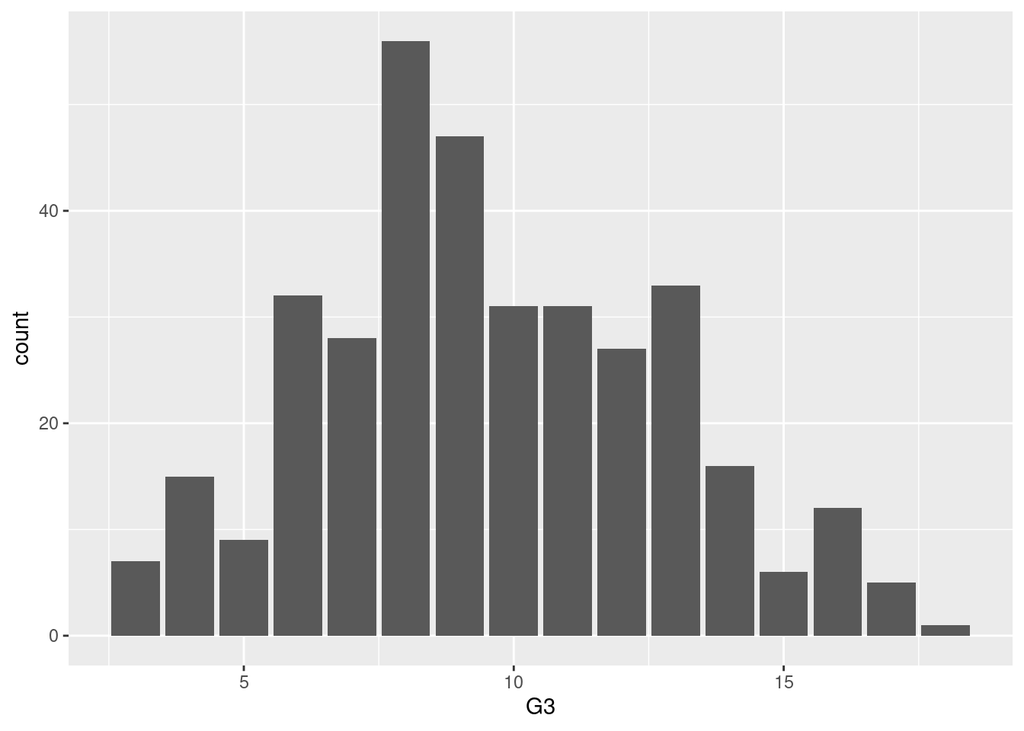

```r
ggplot(data = student4) +
       geom_bar(mapping = aes(x=G3, fill=G3))
```

```r
ggsave("display.0.G3.after.filtering.grade3.frequency.png")
student3 = student4

## FOR CLUSTERING, we may not use the R code below ;

## TRANSFORMING G3 into RANGES of PASS and NO-PASS :

## student3$G3 = as.integer(student3$G3)

## student3$RESULT[student3$G3 <= 10] = "NO_PASS"
## student3$RESULT[student3$G3 >=10 ] = "PASS"

## student3 <- subset(student3, select = -c(G3))

## student3$RESULT = as.factor(student3$RESULT)

## DISPLAYING THE FEATURES (ATTRIBUTES) in THE CURRENT DATASET :

colnames(student3)
```

```
## [1] "age"        "traveltime" "studytime"  "failures"   "absences"
## [6] "G3"
```

```r
summary(student3)
```

```
##       age          traveltime      studytime        failures
##  Min.   :15.00   Min.   :1.000   Min.   :1.000   Min.   :0.0000
##  1st Qu.:16.00   1st Qu.:1.000   1st Qu.:1.000   1st Qu.:0.0000
##  Median :17.00   Median :1.000   Median :2.000   Median :0.0000
##  Mean   :16.65   Mean   :1.433   Mean   :2.042   Mean   :0.2669
##  3rd Qu.:18.00   3rd Qu.:2.000   3rd Qu.:2.000   3rd Qu.:0.0000
##  Max.   :22.00   Max.   :4.000   Max.   :4.000   Max.   :3.0000
##     absences            G3
##  Min.   : 0.000   Min.   : 3.000
##  1st Qu.: 2.000   1st Qu.: 7.000
##  Median : 4.000   Median : 9.000
##  Mean   : 6.272   Mean   : 9.545
##  3rd Qu.: 8.000   3rd Qu.:12.000
##  Max.   :75.000   Max.   :18.000
```

#### **5. DATA SCALING**

```r
student3 <- na.omit(student3)
dim(student3)
```

```
## [1] 356   6
```

```r
## in order to SCALE the DATA

student3_scaled = scale(student3)
summary(student3_scaled)
```

```
##       age            traveltime        studytime           failures
##  Min.   :-1.3028   Min.   :-0.6300   Min.   :-1.25097   Min.   :-0.4004
##  1st Qu.:-0.5154   1st Qu.:-0.6300   1st Qu.:-1.25097   1st Qu.:-0.4004
##  Median : 0.2721   Median :-0.6300   Median :-0.05058   Median :-0.4004
##  Mean   : 0.0000   Mean   : 0.0000   Mean   : 0.00000   Mean   : 0.0000
##  3rd Qu.: 1.0595   3rd Qu.: 0.8263   3rd Qu.:-0.05058   3rd Qu.:-0.4004
##  Max.   : 4.2093   Max.   : 3.7390   Max.   : 2.35020   Max.   : 4.1014
##     absences             G3
##  Min.   :-0.7690   Min.   :-2.0405
##  1st Qu.:-0.5238   1st Qu.:-0.7934
##  Median :-0.2786   Median :-0.1699
##  Mean   : 0.0000   Mean   : 0.0000
##  3rd Qu.: 0.2118   3rd Qu.: 0.7654
##  Max.   : 8.4259   Max.   : 2.6360
```

#### **5. K-MEANS CLUSTERING**

#### **5.1. K-MEANS CLUSTERING (WSS)**

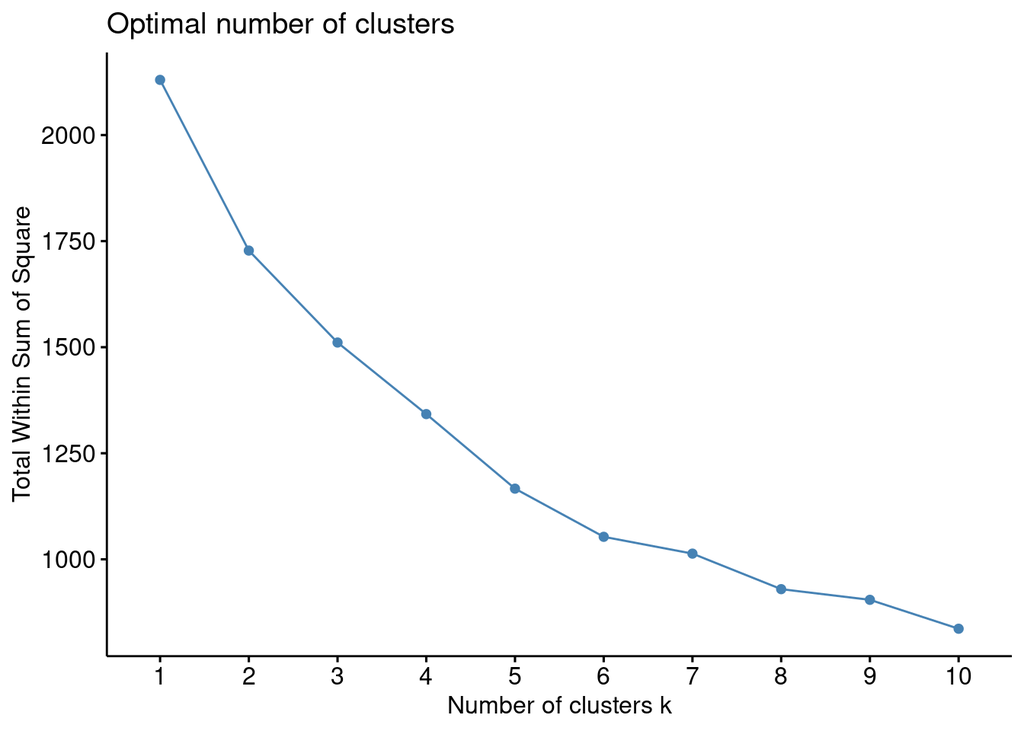

```r
## Looking at the OPTIMAL NUMBER of CLUSTERS by WSS method
## i.e. "within cluster sums of squares"

optimalclusters_WSS <- fviz_nbclust(student3_scaled, kmeans, method="wss")
print(optimalclusters_WSS)
```

```r
## Running the K-MEANS clustering algorithm by using 7 CLUSTERS
kmeans.df <- kmeans(student3_scaled, 7, nstart=25)
print(kmeans.df)
```

```
## K-means clustering with 7 clusters of sizes 64, 12, 86, 73, 79, 28, 14
##
## Cluster means:
##           age traveltime  studytime   failures    absences         G3
## 1 -0.04783343 -0.2431478  1.5812008 -0.3535504 -0.28434990  0.5461968
## 2  0.40331227  0.2195404 -0.2506430  0.2248110  3.73651831 -0.4556840
## 3 -0.53369731 -0.4775788 -0.5949407 -0.3306486 -0.35273277  0.9212931
## 4  0.23970875  1.3649871 -0.3301209 -0.2154374 -0.17615723 -0.3236451
## 5 -0.18644781 -0.6115509 -0.1417470 -0.3814494  0.01004804 -0.7026650
## 6  1.67823830 -0.3699265 -0.1791913  1.6361019  0.54894103 -0.5262030
## 7 -0.40289095  0.9303681 -0.4792886  3.4582749  0.02789474 -1.0606631
##
## Clustering vector:
##   1   2   3   4   5   6   7   8   9  10  11  12  13  14  15  16  17  18  19  20
##   4   5   7   1   5   3   5   4   3   3   5   4   3   4   1   3   1   4   7   5
```

[output cut: 43 more lines]

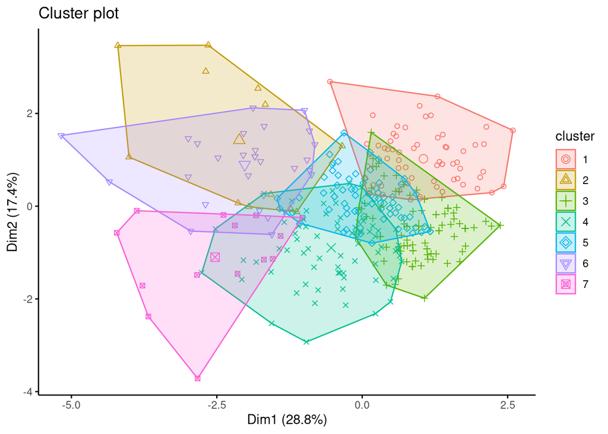

```r
## Visualization :
optimalclusters_WSS_fviz = fviz_cluster(kmeans.df,
                                        data = student3_scaled,
                                        geom = c("point"),
                                        ggtheme=theme_classic())

gridExtra::grid.arrange(optimalclusters_WSS_fviz)
```

```r
## Numerical SUMMARY of the CLUSTERS
clusters_aggregate <- aggregate(student3, by=list(cluster=kmeans.df$cluster), mean)
print(clusters_aggregate)
```

```
##   cluster      age traveltime studytime   failures  absences        G3
## 1       1 16.59375   1.265625  3.359375 0.03125000  3.953125 11.296875
## 2       2 17.16667   1.583333  1.833333 0.41666667 36.750000  8.083333
## 3       3 15.97674   1.104651  1.546512 0.04651163  3.395349 12.500000
## 4       4 16.95890   2.369863  1.767123 0.12328767  4.835616  8.506849
## 5       5 16.41772   1.012658  1.924051 0.01265823  6.354430  7.291139
## 6       6 18.78571   1.178571  1.892857 1.35714286 10.750000  7.857143
## 7       7 16.14286   2.071429  1.642857 2.57142857  6.500000  6.142857
```

```r
student3 %>%
  mutate(Cluster = kmeans.df$cluster) %>%
  group_by(Cluster) %>%
  summarise_all("mean")
```

```
## # A tibble: 7 × 7
##   Cluster   age traveltime studytime failures absences    G3
##     <int> <dbl>      <dbl>     <dbl>    <dbl>    <dbl> <dbl>
## 1       1  16.6       1.27      3.36   0.0312     3.95 11.3
## 2       2  17.2       1.58      1.83   0.417     36.8   8.08
## 3       3  16.0       1.10      1.55   0.0465     3.40 12.5
## 4       4  17.0       2.37      1.77   0.123      4.84  8.51
## 5       5  16.4       1.01      1.92   0.0127     6.35  7.29
## 6       6  18.8       1.18      1.89   1.36      10.8   7.86
## 7       7  16.1       2.07      1.64   2.57       6.5   6.14
```

```r
### Just in case that we will need the information on CLUSTERS in the BIG DATA FRAME

clusterbind_student3 <- cbind(student3, kmeans.df$cluster)
head(clusterbind_student3)
```

```
##   age traveltime studytime failures absences G3 kmeans.df$cluster
## 1  18          2         2        0        6  4                 4
## 2  17          1         2        0        4  4                 5
## 3  15          1         2        3       10  8                 7
## 4  15          1         3        0        2 13                 1
## 5  16          1         2        0        4  8                 5
## 6  16          1         2        0       10 13                 3
```

```r
tail(clusterbind_student3)
```

```
##     age traveltime studytime failures absences G3 kmeans.df$cluster
## 389  18          1         2        0        0  6                 5
## 391  20          1         2        2       11  7                 6
## 392  17          2         1        0        3 14                 3
## 393  21          1         1        3        3  5                 6
## 394  18          3         1        0        0  8                 4
## 395  19          1         1        0        5  7                 5
```

#### **5.2. K-MEANS CLUSTERING (GAP)**

```r
## Looking at the OPTIMAL NUMBER of CLUSTERS by GAP method

optimalclusters_GAP <- fviz_nbclust(student3_scaled, kmeans, method="gap_stat",
                                    nstart=25, nboot=50) +
                                    labs(subtitle = "Gap Statistic Method")
```

```
## Clustering k = 1,2,..., K.max (= 10): .. done
## Bootstrapping, b = 1,2,..., B (= 50)  [one "." per sample]:
## .................................................. 50
```

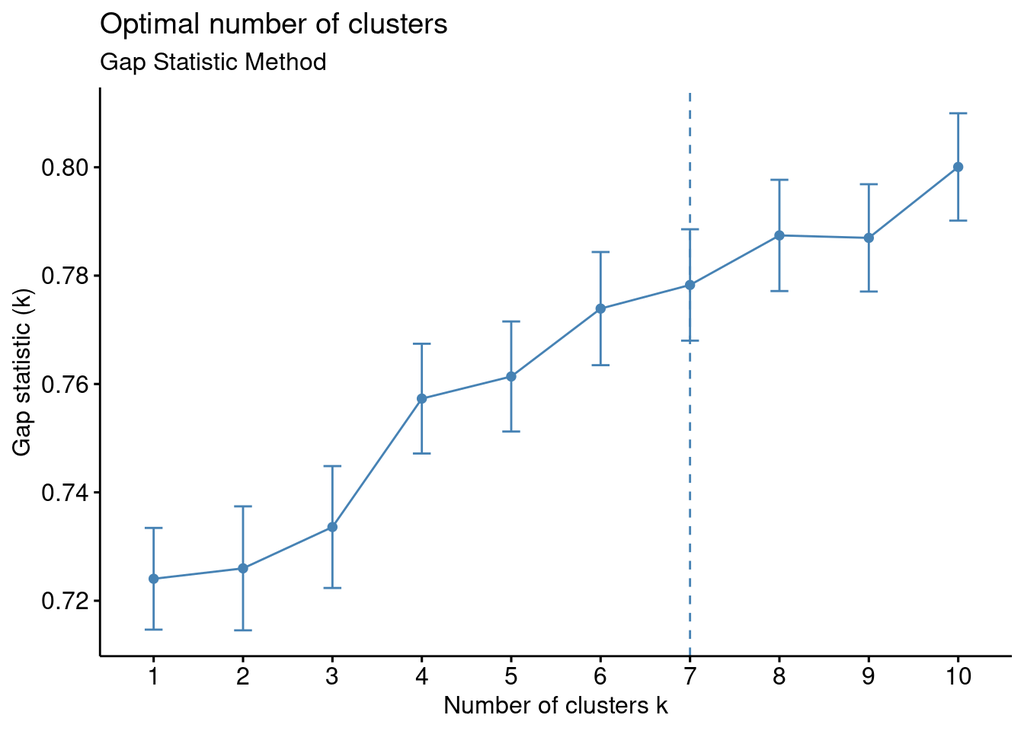

```r
print(optimalclusters_GAP)
```

```r
## Running the K-MEANS clustering algorithm by using 7 CLUSTERS
kmeans.df <- kmeans(student3_scaled, 7, nstart=25)
print(kmeans.df)
```

```
## K-means clustering with 7 clusters of sizes 64, 12, 86, 73, 79, 28, 14
##
## Cluster means:
##           age traveltime  studytime   failures    absences         G3
## 1 -0.04783343 -0.2431478  1.5812008 -0.3535504 -0.28434990  0.5461968
## 2  0.40331227  0.2195404 -0.2506430  0.2248110  3.73651831 -0.4556840
## 3 -0.53369731 -0.4775788 -0.5949407 -0.3306486 -0.35273277  0.9212931
## 4  0.23970875  1.3649871 -0.3301209 -0.2154374 -0.17615723 -0.3236451
## 5 -0.18644781 -0.6115509 -0.1417470 -0.3814494  0.01004804 -0.7026650
## 6  1.67823830 -0.3699265 -0.1791913  1.6361019  0.54894103 -0.5262030
## 7 -0.40289095  0.9303681 -0.4792886  3.4582749  0.02789474 -1.0606631
##
## Clustering vector:
##   1   2   3   4   5   6   7   8   9  10  11  12  13  14  15  16  17  18  19  20
##   4   5   7   1   5   3   5   4   3   3   5   4   3   4   1   3   1   4   7   5
```

[output cut: 43 more lines]

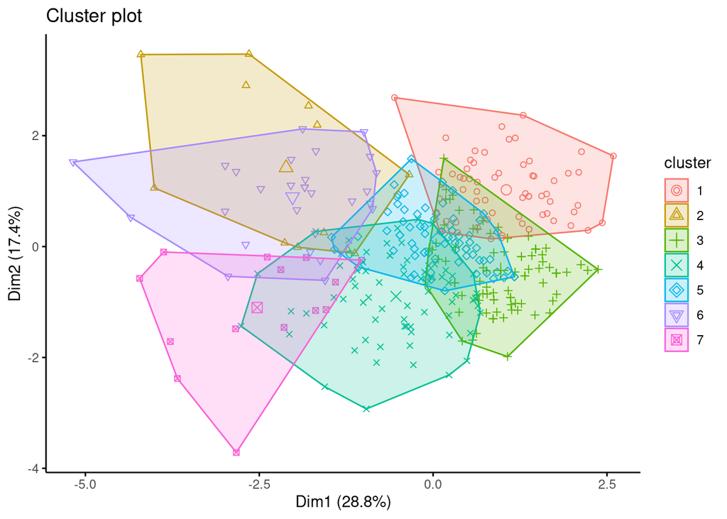

```r
## Visualization :
optimalclusters_GAP_fviz = fviz_cluster(kmeans.df,
                                        data = student3_scaled,
                                        geom = c("point"),
                                        ggtheme=theme_classic())

gridExtra::grid.arrange(optimalclusters_GAP_fviz)
```

```r
## Numerical SUMMARY of the CLUSTERS
clusters_aggregate <- aggregate(student3, by=list(cluster=kmeans.df$cluster), mean)
print(clusters_aggregate)
```

```
##   cluster      age traveltime studytime   failures  absences        G3
## 1       1 16.59375   1.265625  3.359375 0.03125000  3.953125 11.296875
## 2       2 17.16667   1.583333  1.833333 0.41666667 36.750000  8.083333
## 3       3 15.97674   1.104651  1.546512 0.04651163  3.395349 12.500000
## 4       4 16.95890   2.369863  1.767123 0.12328767  4.835616  8.506849
## 5       5 16.41772   1.012658  1.924051 0.01265823  6.354430  7.291139
## 6       6 18.78571   1.178571  1.892857 1.35714286 10.750000  7.857143
## 7       7 16.14286   2.071429  1.642857 2.57142857  6.500000  6.142857
```

```r
student3 %>%
  mutate(Cluster = kmeans.df$cluster) %>%
  group_by(Cluster) %>%
  summarise_all("mean")
```

```
## # A tibble: 7 × 7
##   Cluster   age traveltime studytime failures absences    G3
##     <int> <dbl>      <dbl>     <dbl>    <dbl>    <dbl> <dbl>
## 1       1  16.6       1.27      3.36   0.0312     3.95 11.3
## 2       2  17.2       1.58      1.83   0.417     36.8   8.08
## 3       3  16.0       1.10      1.55   0.0465     3.40 12.5
## 4       4  17.0       2.37      1.77   0.123      4.84  8.51
## 5       5  16.4       1.01      1.92   0.0127     6.35  7.29
## 6       6  18.8       1.18      1.89   1.36      10.8   7.86
## 7       7  16.1       2.07      1.64   2.57       6.5   6.14
```

```r
### just in case that we will need the information on CLUSTERS in the BIG DATA FRAME

clusterbind_student3 <- cbind(student3, kmeans.df$cluster)
head(clusterbind_student3)
```

```
##   age traveltime studytime failures absences G3 kmeans.df$cluster
## 1  18          2         2        0        6  4                 4
## 2  17          1         2        0        4  4                 5
## 3  15          1         2        3       10  8                 7
## 4  15          1         3        0        2 13                 1
## 5  16          1         2        0        4  8                 5
## 6  16          1         2        0       10 13                 3
```

```r
tail(clusterbind_student3)
```

```
##     age traveltime studytime failures absences G3 kmeans.df$cluster
## 389  18          1         2        0        0  6                 5
## 391  20          1         2        2       11  7                 6
## 392  17          2         1        0        3 14                 3
## 393  21          1         1        3        3  5                 6
## 394  18          3         1        0        0  8                 4
## 395  19          1         1        0        5  7                 5
```

#### **5.3. K-MEANS CLUSTERING (SILHOUETTE)**

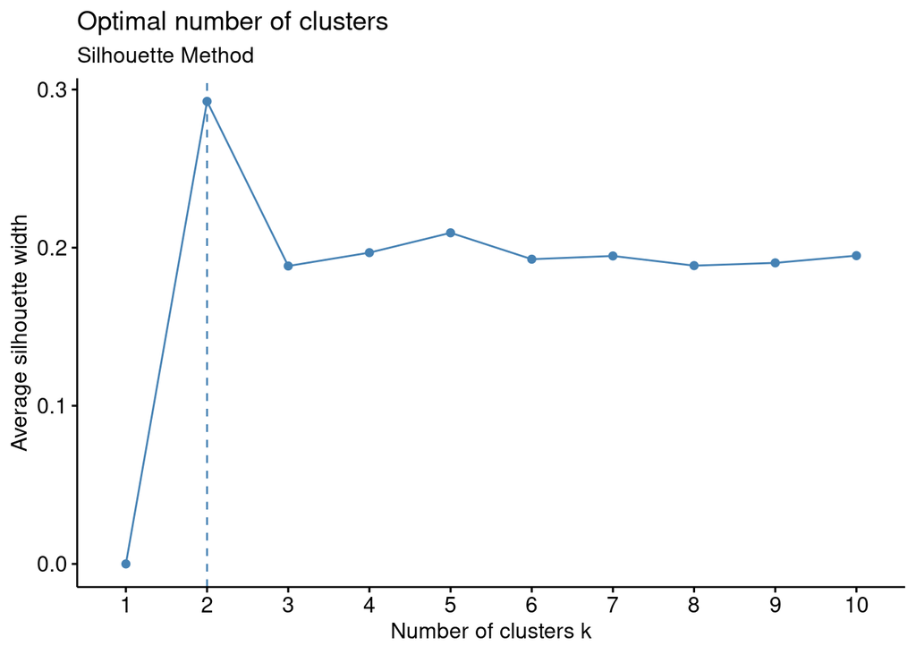

```r
## Using K-MEANS
## Looking at the OPTIMAL NUMBER of CLUSTERS by SILHOUETTE METHOD

optimalclusters_SILHOUETTE <- fviz_nbclust(student3_scaled, kmeans, nstart=25,
                                           method="silhouette", nboot=50) +
                                           labs(subtitle = "Silhouette Method")
print(optimalclusters_SILHOUETTE)
```

```r
## Running the K-MEANS clustering algorithm by using 2 CLUSTERS
kmeans.df <- kmeans(student3_scaled, 2, nstart=25)
print(kmeans.df)
```

```
## K-means clustering with 2 clusters of sizes 84, 272
##
## Cluster means:
##          age traveltime  studytime   failures   absences         G3
## 1  0.7220438  0.6009601 -0.4507079  1.1716264  0.7999773 -0.7488947
## 2 -0.2229841 -0.1855906  0.1391892 -0.3618258 -0.2470518  0.2312763
##
## Clustering vector:
##   1   2   3   4   5   6   7   8   9  10  11  12  13  14  15  16  17  18  19  20
##   1   2   1   2   2   2   2   1   2   2   2   2   2   2   2   2   2   2   1   2
##  21  22  23  24  25  26  27  28  29  30  31  32  33  34  35  36  37  38  39  40
##   2   2   2   2   2   1   2   2   2   2   2   2   2   2   2   2   2   2   2   2
##  41  42  43  44  45  46  47  48  49  50  51  52  53  54  55  56  57  58  59  60
##   1   2   2   2   1   2   2   2   2   2   2   2   1   2   2   2   2   2   2   2
##  61  62  63  64  65  66  67  68  69  70  71  72  73  74  75  76  77  78  79  80
```

[output cut: 38 more lines]

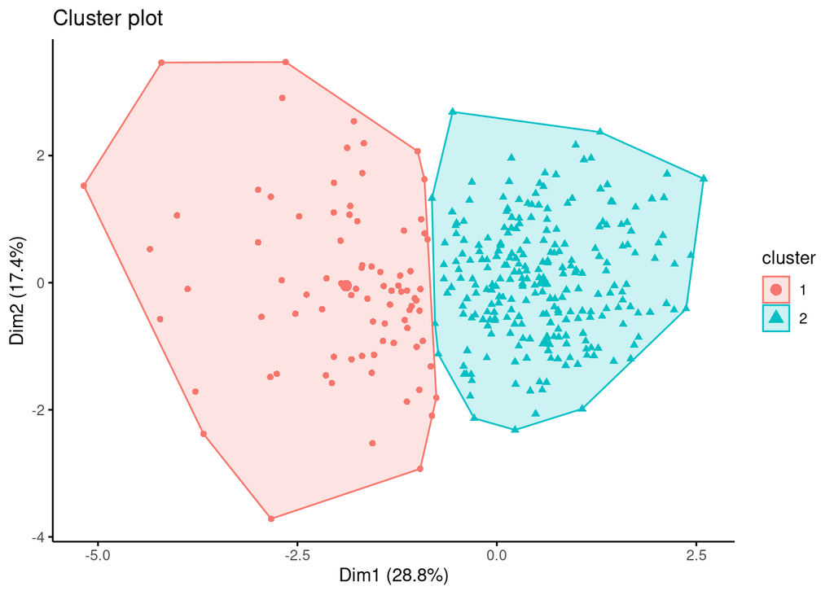

```r
## Visualization :
optimalclusters_SILHOUETTE_fviz = fviz_cluster(kmeans.df,
                                        data = student3_scaled,
                                        geom = c("point"),
                                        ggtheme=theme_classic())

gridExtra::grid.arrange(optimalclusters_SILHOUETTE_fviz)
```

```r
## Numerical SUMMARY of the CLUSTERS
clusters_aggregate <- aggregate(student3, by=list(cluster=kmeans.df$cluster), mean)
print(clusters_aggregate)
```

```
##   cluster      age traveltime studytime   failures  absences        G3
## 1       1 17.57143   1.845238  1.666667 1.04761905 12.797619  7.142857
## 2       2 16.37132   1.305147  2.158088 0.02573529  4.257353 10.286765
```

```r
student3 %>%
  mutate(Cluster = kmeans.df$cluster) %>%
  group_by(Cluster) %>%
  summarise_all("mean")
```

```
## # A tibble: 2 × 7
##   Cluster   age traveltime studytime failures absences    G3
##     <int> <dbl>      <dbl>     <dbl>    <dbl>    <dbl> <dbl>
## 1       1  17.6       1.85      1.67   1.05      12.8   7.14
## 2       2  16.4       1.31      2.16   0.0257     4.26 10.3
```

```r
### just in case that we will need the information on CLUSTERS in the BIG DATA FRAME

clusterbind_student3 <- cbind(student3, kmeans.df$cluster)
head(clusterbind_student3)
```

```
##   age traveltime studytime failures absences G3 kmeans.df$cluster
## 1  18          2         2        0        6  4                 1
## 2  17          1         2        0        4  4                 2
## 3  15          1         2        3       10  8                 1
## 4  15          1         3        0        2 13                 2
## 5  16          1         2        0        4  8                 2
## 6  16          1         2        0       10 13                 2
```

```r
tail(clusterbind_student3)
```

[output not shown]

```r
## Comparing the summaries above to the dataset grouped by GRADE G3
## (age, traveltime, studytime, failures, absences, G3)

## tapply(student3$age, student3$G3, summary)
## tapply(student3$traveltime, student3$G3, summary)
## tapply(student3$studytime, student3$G3, summary)
## tapply(student3$failures, student3$G3, summary)
## tapply(student3$absences, student3$G3, summary)
## tapply(student3$G3, student3$G3, summary)
```

#### **5.4. PAM-based CLUSTERING (after SILHOUETTE method)**

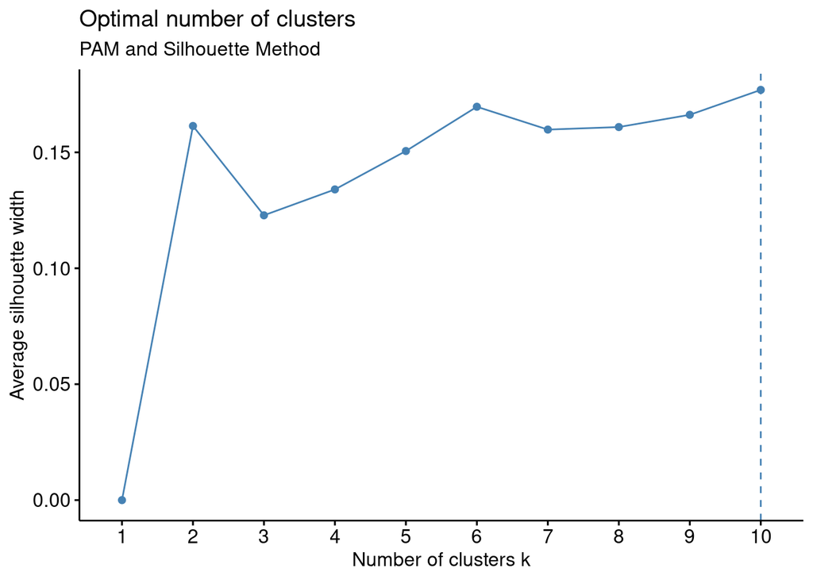

```r
## Using PAM Partitioning Around Medoids
## Looking at the OPTIMAL NUMBER of CLUSTERS by SILHOUETTE

optimalclusters_PAM <- fviz_nbclust(student3_scaled,
                                           pam,
                                           method="silhouette") +
                                           labs(subtitle = "PAM and Silhouette Method")
print(optimalclusters_PAM)
```

```r
#  Using "PAM" function for Partitioning (clustering) of the data into ‘k’ clusters
# "around medoids"", a more robust version of K-means.
```

```r
pam_clusters <- pam(student3_scaled, 2)

print(pam_clusters)
```

```
## Medoids:
##      ID        age traveltime   studytime   failures    absences         G3
## 276 250  0.2720699  0.8263445 -0.05057819 -0.4004445 -0.03340482  0.1418721
## 29   29 -0.5153844 -0.6299854 -0.05057819 -0.4004445 -0.27860307 -0.1698963
## Clustering vector:
##   1   2   3   4   5   6   7   8   9  10  11  12  13  14  15  16  17  18  19  20
##   1   2   2   2   2   2   2   1   2   2   2   1   2   2   2   2   2   1   2   2
##  21  22  23  24  25  26  27  28  29  30  31  32  33  34  35  36  37  38  39  40
##   2   2   2   1   2   2   2   2   2   2   2   1   2   2   2   2   2   1   2   2
##  41  42  43  44  45  46  47  48  49  50  51  52  53  54  55  56  57  58  59  60
##   1   2   2   2   1   2   2   2   2   2   1   2   1   2   2   2   2   2   2   2
##  61  62  63  64  65  66  67  68  69  70  71  72  73  74  75  76  77  78  79  80
##   2   1   2   2   2   1   2   2   2   1   1   2   2   2   1   2   1   2   1   2
##  81  82  83  84  85  86  87  88  89  90  91  92  93  94  95  96  97  98  99 100
##   2   2   2   1   2   2   2   2   1   2   2   2   2   1   2   2   1   2   2   2
```

[output cut: 33 more lines]

```r
str(pam_clusters)
```

```
## List of 10
##  $ medoids   : num [1:2, 1:6] 0.2721 -0.5154 0.8263 -0.63 -0.0506 ...
##   ..- attr(*, "dimnames")=List of 2
##   .. ..$ : chr [1:2] "276" "29"
##   .. ..$ : chr [1:6] "age" "traveltime" "studytime" "failures" ...
##  $ id.med    : int [1:2] 250 29
##  $ clustering: Named int [1:356] 1 2 2 2 2 2 2 1 2 2 ...
##   ..- attr(*, "names")= chr [1:356] "1" "2" "3" "4" ...
##  $ objective : Named num [1:2] 2.08 2.06
##   ..- attr(*, "names")= chr [1:2] "build" "swap"
##  $ isolation : Factor w/ 3 levels "no","L","L*": 1 1
##   ..- attr(*, "names")= chr [1:2] "1" "2"
##  $ clusinfo  : num [1:2, 1:5] 151 205 8.55 5.29 2.45 ...
##   ..- attr(*, "dimnames")=List of 2
##   .. ..$ : NULL
##   .. ..$ : chr [1:5] "size" "max_diss" "av_diss" "diameter" ...
##  $ silinfo   :List of 3
##   ..$ widths         : num [1:356, 1:3] 1 1 1 1 1 1 1 1 1 1 ...
##   .. ..- attr(*, "dimnames")=List of 2
##   .. .. ..$ : chr [1:356] "370" "229" "312" "354" ...
##   .. .. ..$ : chr [1:3] "cluster" "neighbor" "sil_width"
##   ..$ clus.avg.widths: num [1:2] -0.00856 0.28653
##   ..$ avg.width      : num 0.161
##  $ diss      : NULL
##  $ call      : language pam(x = student3_scaled, k = 2)
##  $ data      : num [1:356, 1:6] 1.06 0.272 -1.303 -1.303 -0.515 ...
##   ..- attr(*, "scaled:center")= Named num [1:6] 16.654 1.433 2.042 0.267 6.272 ...
##   .. ..- attr(*, "names")= chr [1:6] "age" "traveltime" "studytime" "failures" ...
##   ..- attr(*, "scaled:scale")= Named num [1:6] 1.27 0.687 0.833 0.666 8.157 ...
##   .. ..- attr(*, "names")= chr [1:6] "age" "traveltime" "studytime" "failures" ...
##   ..- attr(*, "dimnames")=List of 2
##   .. ..$ : chr [1:356] "1" "2" "3" "4" ...
##   .. ..$ : chr [1:6] "age" "traveltime" "studytime" "failures" ...
##  - attr(*, "class")= chr [1:2] "pam" "partition"
```

```r
print(pam_clusters$medoids)
```

```
##            age traveltime   studytime   failures    absences         G3
## 276  0.2720699  0.8263445 -0.05057819 -0.4004445 -0.03340482  0.1418721
## 29  -0.5153844 -0.6299854 -0.05057819 -0.4004445 -0.27860307 -0.1698963
```

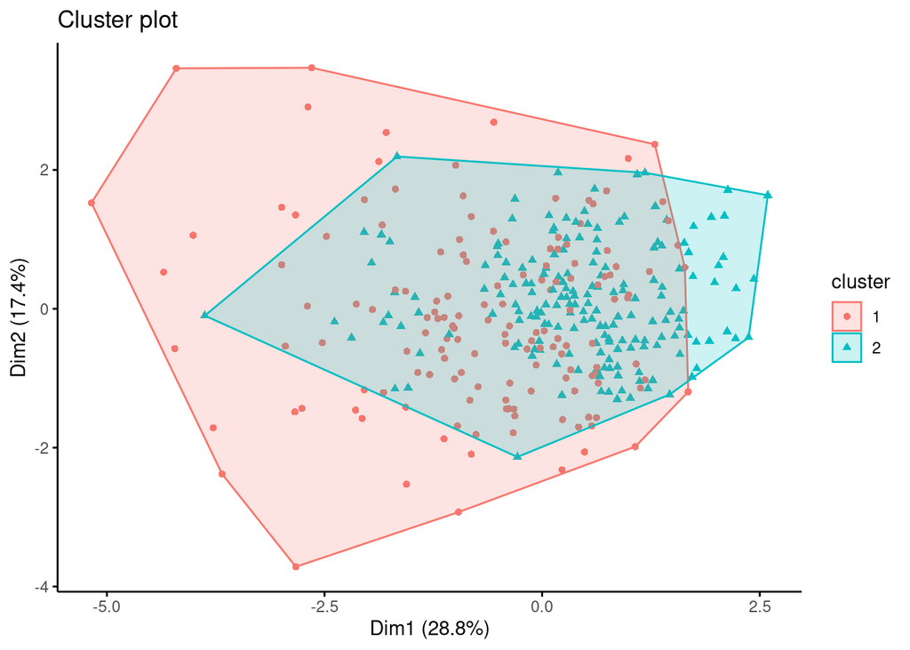

```r
## Visualization :
optimalclusters_SILHOUETTE_fviz = fviz_cluster(pam_clusters,
                                               data = student3_scaled,
                                               geom = c("point"),
                                               ggtheme=theme_classic())

gridExtra::grid.arrange(optimalclusters_SILHOUETTE_fviz)
```

```r
## Numerical SUMMARY of the CLUSTERS
pamclusters_aggregate <- aggregate(student3, by=list(cluster=pam_clusters$cluster), mean)
print(pamclusters_aggregate)
```

```
##   cluster      age traveltime studytime  failures absences       G3
## 1       1 17.34437   1.980132  2.013245 0.4105960 8.039735 9.536424
## 2       2 16.14634   1.029268  2.063415 0.1609756 4.970732 9.551220
```

```r
student3 %>%
  mutate(Cluster = pam_clusters$cluster) %>%
  group_by(Cluster) %>%
  summarise_all("mean")
```

```
## # A tibble: 2 × 7
##   Cluster   age traveltime studytime failures absences    G3
##     <int> <dbl>      <dbl>     <dbl>    <dbl>    <dbl> <dbl>
## 1       1  17.3       1.98      2.01    0.411     8.04  9.54
## 2       2  16.1       1.03      2.06    0.161     4.97  9.55
```

```r
### just in case that we will need the information on CLUSTERS in the BIG DATA FRAME

clusterbind_student3 <- cbind(student3, pam_clusters$cluster)
head(clusterbind_student3)
```

```
##   age traveltime studytime failures absences G3 pam_clusters$cluster
## 1  18          2         2        0        6  4                    1
## 2  17          1         2        0        4  4                    2
## 3  15          1         2        3       10  8                    2
## 4  15          1         3        0        2 13                    2
## 5  16          1         2        0        4  8                    2
## 6  16          1         2        0       10 13                    2
```

```r
tail(clusterbind_student3)
```

```
##     age traveltime studytime failures absences G3 pam_clusters$cluster
## 389  18          1         2        0        0  6                    2
## 391  20          1         2        2       11  7                    1
## 392  17          2         1        0        3 14                    1
## 393  21          1         1        3        3  5                    1
## 394  18          3         1        0        0  8                    1
## 395  19          1         1        0        5  7                    1
```

#### **6. HIERARCHICAL CLUSTERING**

#### **6.1 HIERARCHICAL CLUSTERING (using EUCLIDEAN distance)**

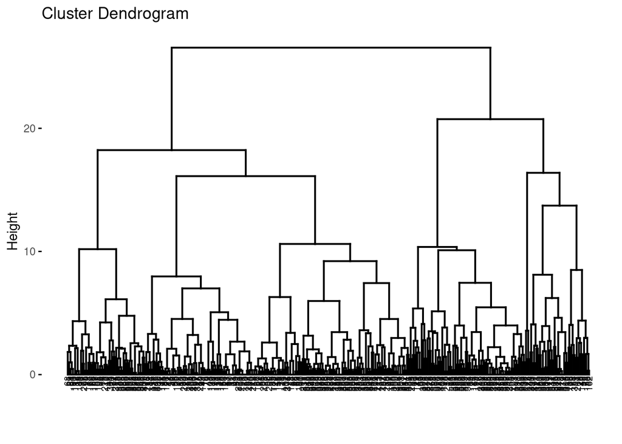

```r
student3_dist = dist(student3_scaled, method="euclidean")
# as.matrix(student3_dist)[1:2,1:2]

agg_tree_ward = hclust(d = student3_dist, method="ward.D2")
#print(agg_tree_ward)

# Visualizing the Dendogram
fviz_dend(agg_tree_ward, cex=.5)
```

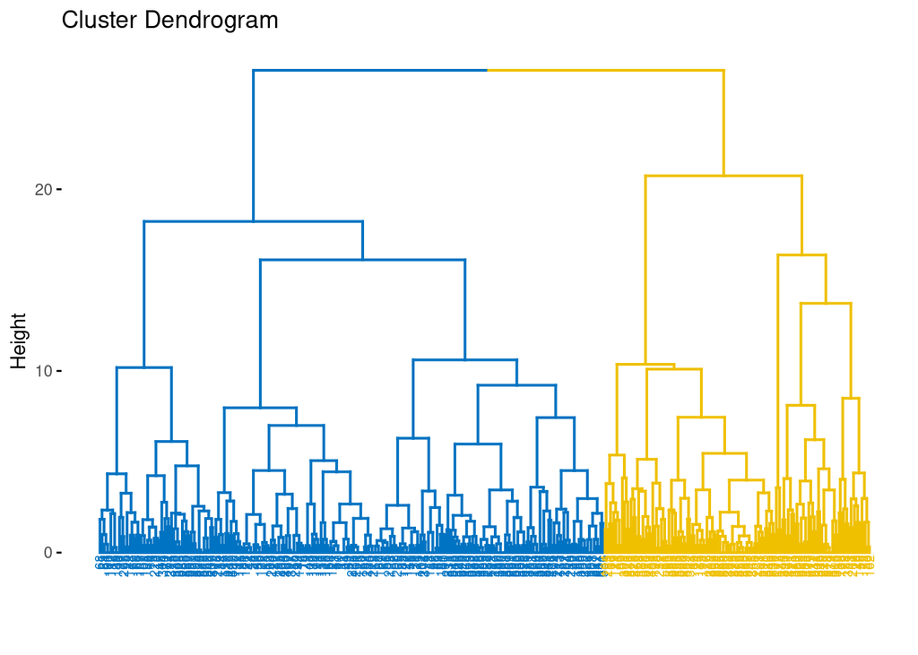

```r
# Cutting the tree to create 2 clusters and visualizing it:
agg_tree_warddend <- fviz_dend(agg_tree_ward, cex=.5, k=2, palette = "jco")
agg_tree_warddend
```

```r
# To access the partition accuracy of the cluster tree (created by hclust()) there should be a strong
# correlation between the original distance matrix and the object linkage distance defined as cophenetic
# distances.
# Calculating Cophenetic Distances

agg_cophenetic <- cophenetic(agg_tree_ward)

# head(agg_cophenetic)
# tail(agg_cophenetic)

# Calculating the correlation between Cophenetic Distances and Original Distances for :
cor(student3_dist, agg_cophenetic)
```

```
## [1] 0.4707307
```

#### **6.2 HIERARCHICAL CLUSTERING (using MINKOWSKI distance)**

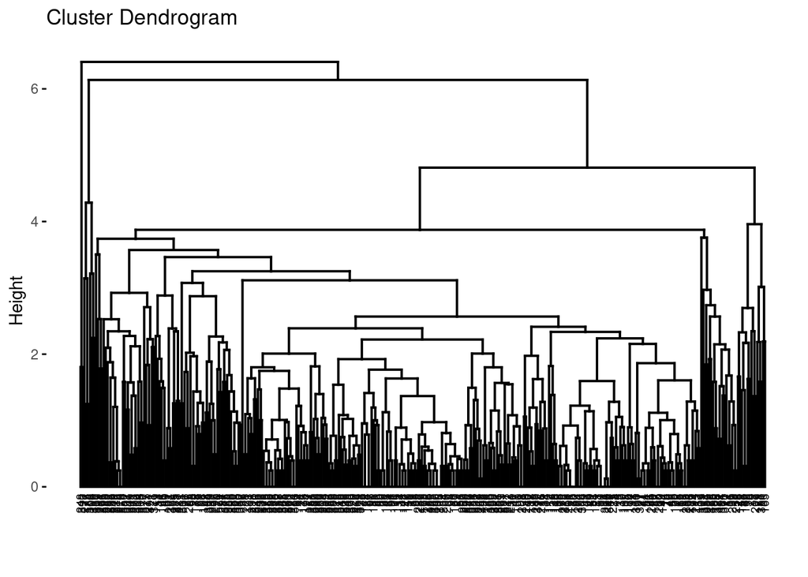

```r
student3_dist = dist(student3_scaled, method="minkowski")
# as.matrix(student3_dist)[1:2,1:2]

agg_tree_ward = hclust(d = student3_dist, method="average")
#print(agg_tree_ward)

# Visualizing the Dendogram
fviz_dend(agg_tree_ward, cex=.5)
```

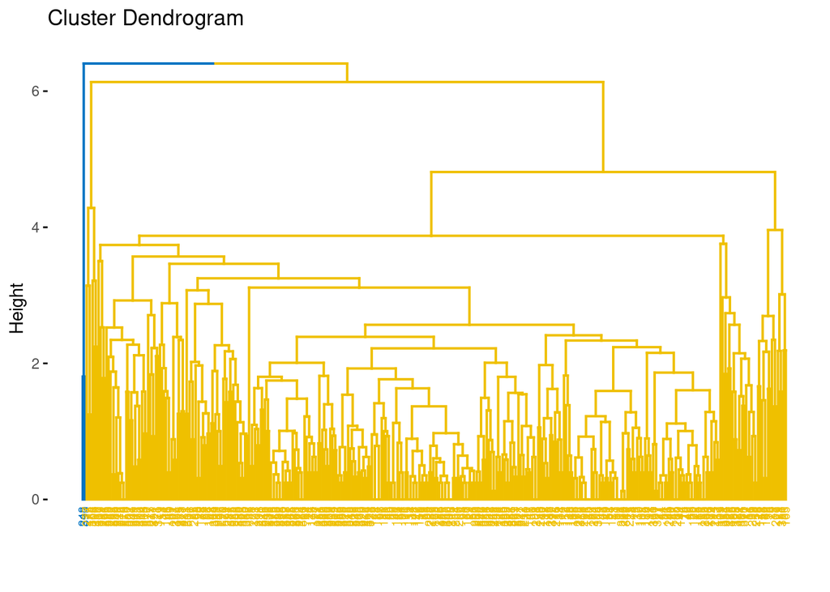

```r
# Cutting the tree to create 2 clusters and visualizing it:
agg_tree_warddend <- fviz_dend(agg_tree_ward, cex=.5, k=2, palette = "jco")
agg_tree_warddend
```

```r
# To access the partition accuracy of the cluster tree (created by hclust()) there should be a strong
# correlation between the original distance matrix and the object linkage distance defined as cophenetic
# distances.
# Calculating Cophenetic Distances

agg_cophenetic <- cophenetic(agg_tree_ward)

# head(agg_cophenetic)
# tail(agg_cophenetic)

# Calculating the correlation between Cophenetic Distances and Original Distances for :
cor(student3_dist, agg_cophenetic)
```

```
## [1] 0.783801
```

#### **6.3 HIERARCHICAL CLUSTERING (using CANBERRA distance)**

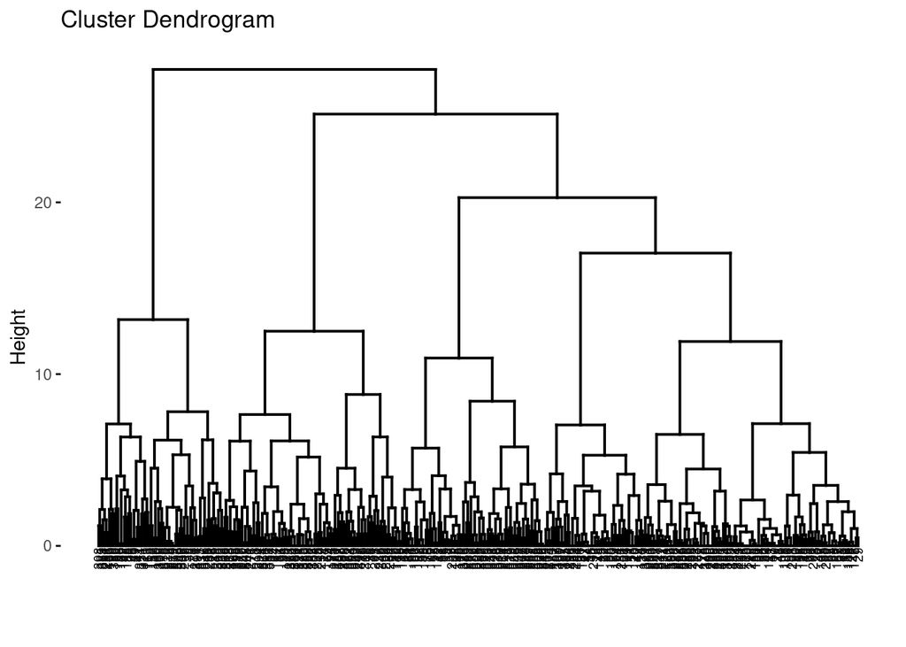

```r
student3_dist = dist(student3_scaled, method="canberra")
# as.matrix(student3_dist)[1:2,1:2]

agg_tree_ward = hclust(d = student3_dist, method="ward.D2")
#print(agg_tree_ward)

# Visualizing the Dendogram
fviz_dend(agg_tree_ward, cex=.5)
```

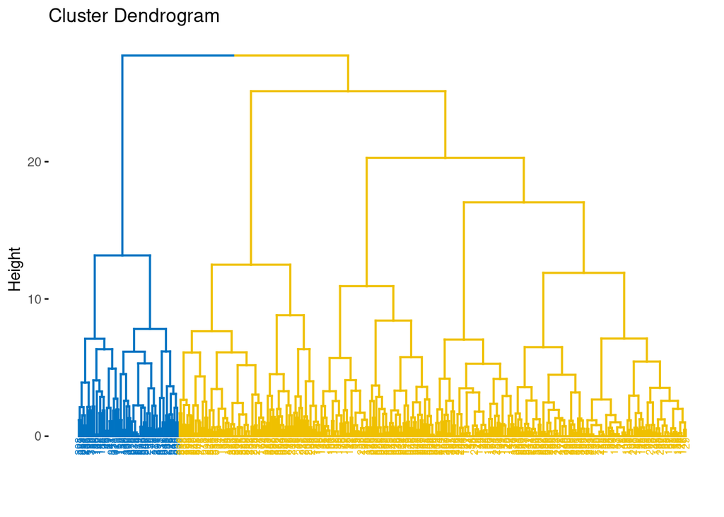

```r
# Cutting the tree to create 2 clusters and visualizing it:
agg_tree_warddend <- fviz_dend(agg_tree_ward, cex=.5, k=2, palette = "jco")
agg_tree_warddend
```

```r
# To access the partition accuracy of the cluster tree (created by hclust()) there should be a strong
# correlation between the original distance matrix and the object linkage distance defined as cophenetic
# distances.
# Calculating Cophenetic Distances

agg_cophenetic <- cophenetic(agg_tree_ward)

# head(agg_cophenetic)
# tail(agg_cophenetic)

# Calculating the correlation between Cophenetic Distances and Original Distances for :
cor(student3_dist, agg_cophenetic)
```

```
## [1] 0.6233455
```

#### **6.4 HIERARCHICAL CLUSTERING (using MANHATTAN distance)**

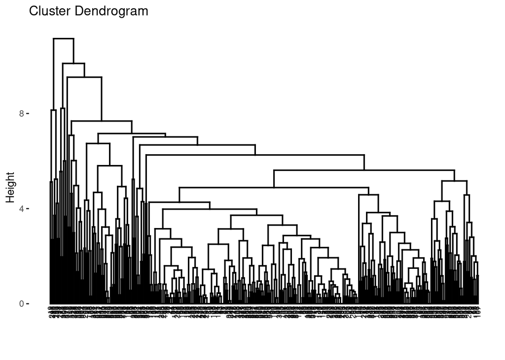

```r
student3_dist = dist(student3_scaled, method="manhattan")
# as.matrix(student3_dist)[1:2,1:2]

agg_tree_ward = hclust(d = student3_dist, method="average")
#print(agg_tree_ward)

# Visualizing the Dendogram
fviz_dend(agg_tree_ward, cex=.5)
```

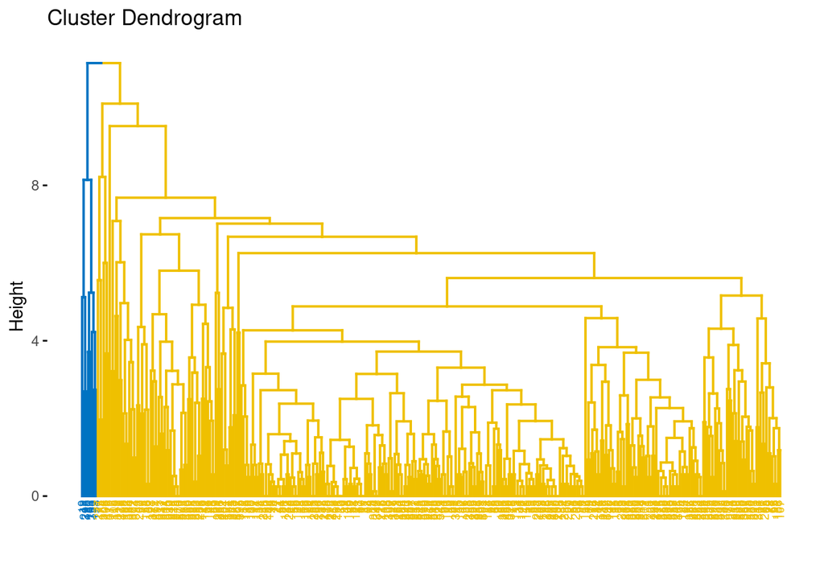

```r
# Cutting the tree to create 2 clusters and visualizing it:
agg_tree_warddend <- fviz_dend(agg_tree_ward, cex=.5, k=2, palette = "jco")
agg_tree_warddend
```

```r
# To access the partition accuracy of the cluster tree (created by hclust()) there should be a strong
# correlation between the original distance matrix and the object linkage distance defined as cophenetic
# distances.
# Calculating Cophenetic Distances

agg_cophenetic <- cophenetic(agg_tree_ward)

# head(agg_cophenetic)
# tail(agg_cophenetic)

# Calculating the correlation between Cophenetic Distances and Original Distances for :
cor(student3_dist, agg_cophenetic)
```

```
## [1] 0.7838249
```

#### **7. HIERARCHICAL CLUSTERING (by AGNES and DIANA)**

#### **7.1 HIERARCHICAL CLUSTERING (by AGNES)**

```r
### AGGLOMERATIVE

agnes_cluster <- agnes(x=student3_scaled, stand=TRUE, metric = "euclidean", method="ward")

str(agnes_cluster)
```

```
## List of 9
##  $ order    : int [1:356] 1 8 202 175 271 220 192 210 216 158 ...
##  $ height   : num [1:355] 1.171 0.759 3.265 1.014 1.957 ...
##  $ ac       : num 0.972
##  $ merge    : int [1:355, 1:2] -266 -258 -249 -212 -196 -185 -178 -173 -172 -162 ...
##  $ diss     : NULL
##  $ call     : language agnes(x = student3_scaled, metric = "euclidean", stand = TRUE, method = "ward")
##  $ method   : chr "ward"
##  $ order.lab: chr [1:356] "1" "8" "221" "193" ...
##  $ data     : num [1:356, 1:6] 1.266 0.325 -1.556 -1.556 -0.616 ...
##   ..- attr(*, "scaled:center")= Named num [1:6] 1.35e-15 -1.10e-16 2.50e-16 4.93e-17 6.19e-17 ...
##   .. ..- attr(*, "names")= chr [1:6] "age" "traveltime" "studytime" "failures" ...
##   ..- attr(*, "scaled:scale")= Named num [1:6] 0.837 0.832 0.698 0.661 0.646 ...
##   .. ..- attr(*, "names")= chr [1:6] "age" "traveltime" "studytime" "failures" ...
##   ..- attr(*, "dimnames")=List of 2
##   .. ..$ : chr [1:356] "1" "2" "3" "4" ...
##   .. ..$ : chr [1:6] "age" "traveltime" "studytime" "failures" ...
##  - attr(*, "class")= chr [1:2] "agnes" "twins"
```

```r
agnes_cluster$ac
```

```
## [1] 0.9718767
```

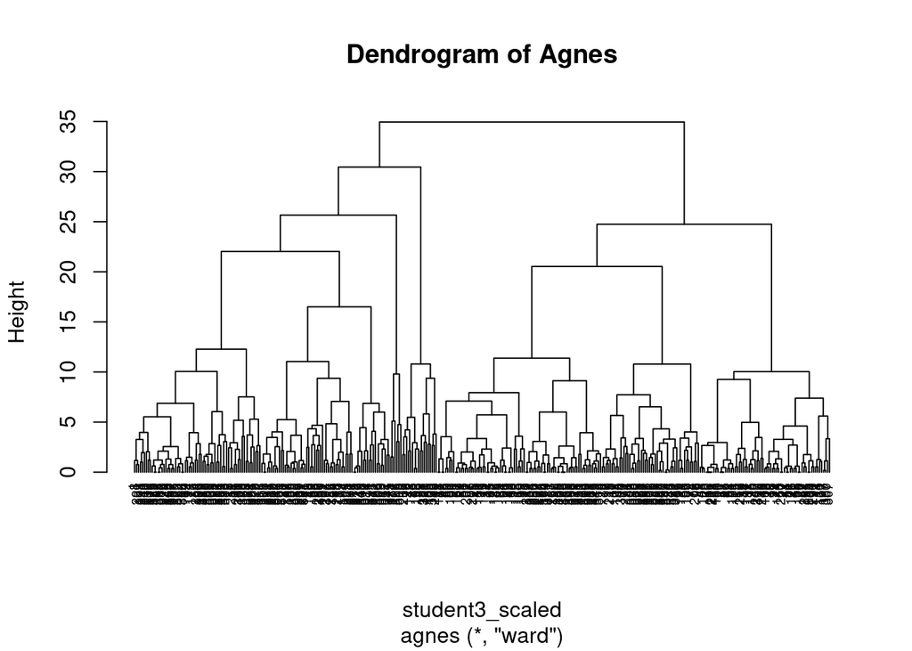

```r
agnes_tree <- pltree(agnes_cluster, cex = 0.6, hang = -1, main = "Dendrogram of Agnes")
```

```r
print(agnes_tree)
```

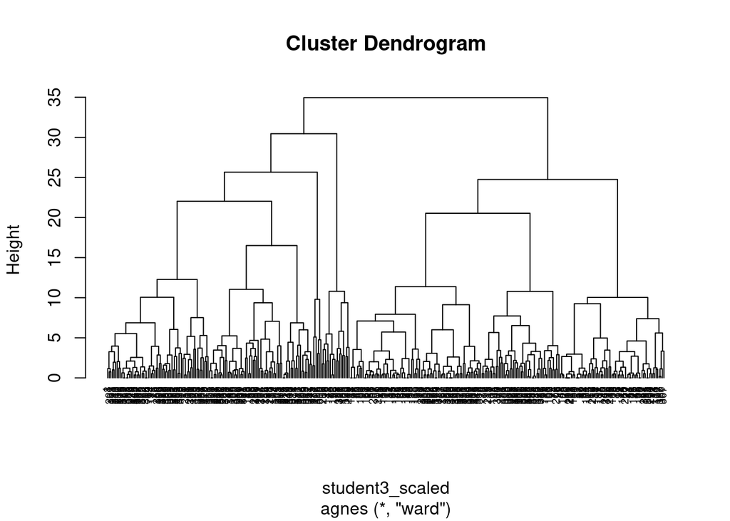

```r
plot(as.hclust(agnes_cluster), cex = 0.6, hang = -1)
```

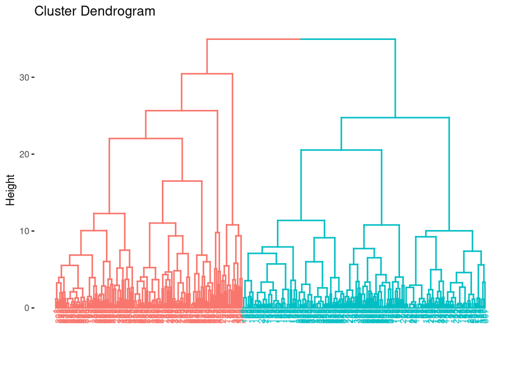

```r
fviz_dend(agnes_cluster, cex=.6, k=2)
```

#### **7.2 HIERARCHICAL CLUSTERING (by DIANA)**

```r
### Divisive
diana_cluster <- diana(x=student3_scaled, stand=TRUE, metric = "euclidean")

str(diana_cluster)
```

```
## List of 8
##  $ order    : int [1:356] 1 8 202 175 271 192 349 14 24 123 ...
##  $ height   : num [1:355] 1.209 0.759 2.045 1.014 2.833 ...
##  $ dc       : num 0.935
##  $ merge    : int [1:355, 1:2] -91 -39 -266 -178 -142 -44 -35 -55 -31 -127 ...
##  $ diss     : NULL
##  $ call     : language diana(x = student3_scaled, metric = "euclidean", stand = TRUE)
##  $ order.lab: chr [1:356] "1" "8" "221" "193" ...
##  $ data     : num [1:356, 1:6] 1.266 0.325 -1.556 -1.556 -0.616 ...
##   ..- attr(*, "scaled:center")= Named num [1:6] 1.35e-15 -1.10e-16 2.50e-16 4.93e-17 6.19e-17 ...
##   .. ..- attr(*, "names")= chr [1:6] "age" "traveltime" "studytime" "failures" ...
##   ..- attr(*, "scaled:scale")= Named num [1:6] 0.837 0.832 0.698 0.661 0.646 ...
##   .. ..- attr(*, "names")= chr [1:6] "age" "traveltime" "studytime" "failures" ...
##   ..- attr(*, "dimnames")=List of 2
##   .. ..$ : chr [1:356] "1" "2" "3" "4" ...
##   .. ..$ : chr [1:6] "age" "traveltime" "studytime" "failures" ...
##  - attr(*, "class")= chr [1:2] "diana" "twins"
```

```r
diana_cluster$dc
```

```
## [1] 0.9352352
```

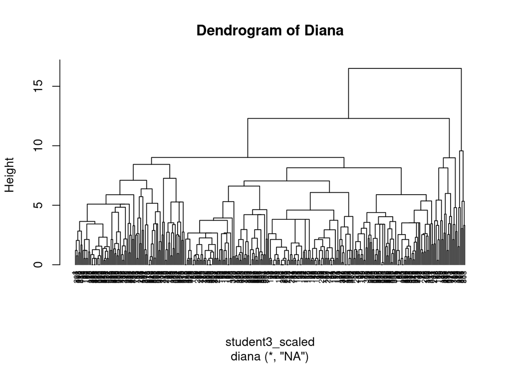

```r
diana_tree <- pltree(diana_cluster, cex = 0.6, hang = -1, main = "Dendrogram of Diana")
```

```r
print(diana_tree)
```

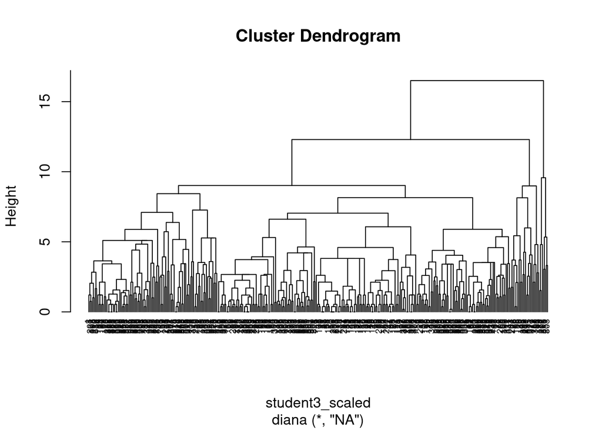

```r
plot(as.hclust(diana_cluster), cex = 0.6, hang = -1)
```

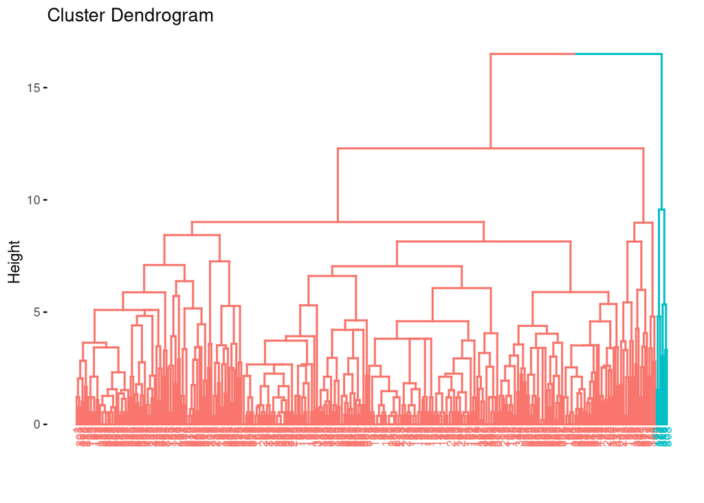

```r
fviz_dend(diana_cluster, cex=.6, k=2)
```

#### **8. HIERARCHICAL CLUSTERING (THE HEATMAPS)**

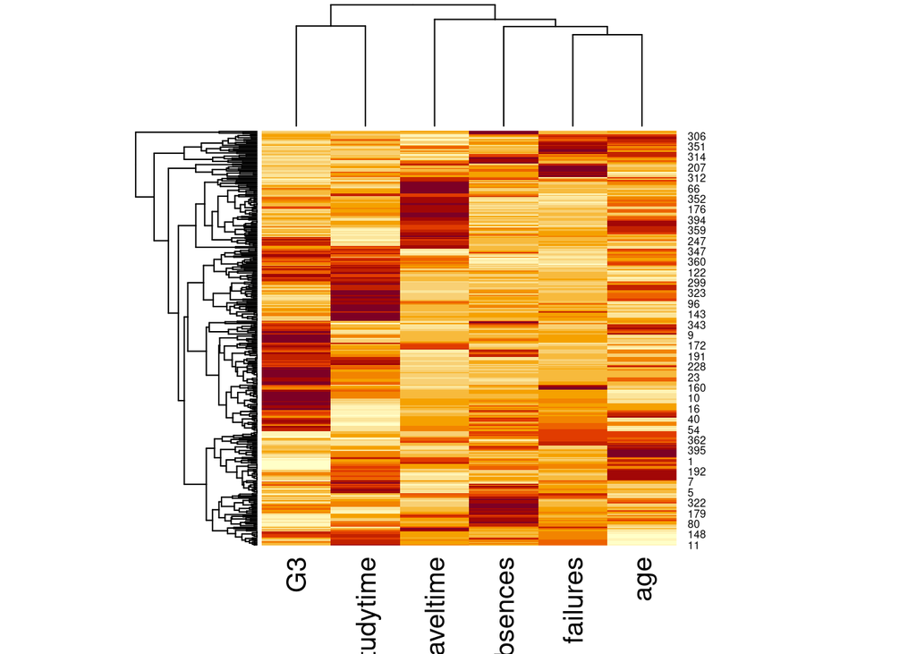

```r
# using HEATMAP : the high values are in red and low in yellow.

heatmap(student3_scaled)
```

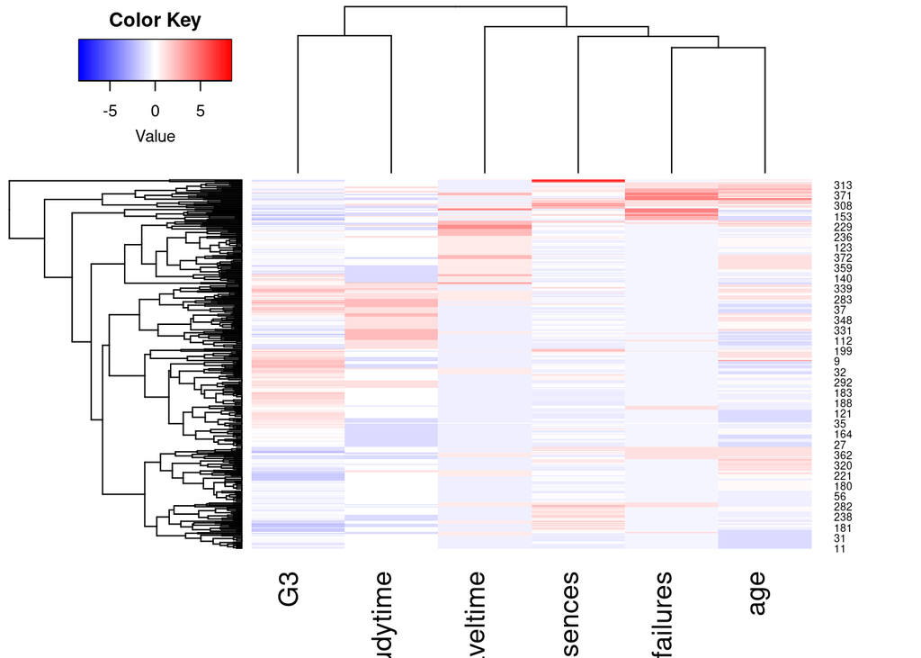

```r
heatmap.2(student3_scaled,
          scale="none",
          col=bluered(100),
          trace = "none", density.info = "none")
```

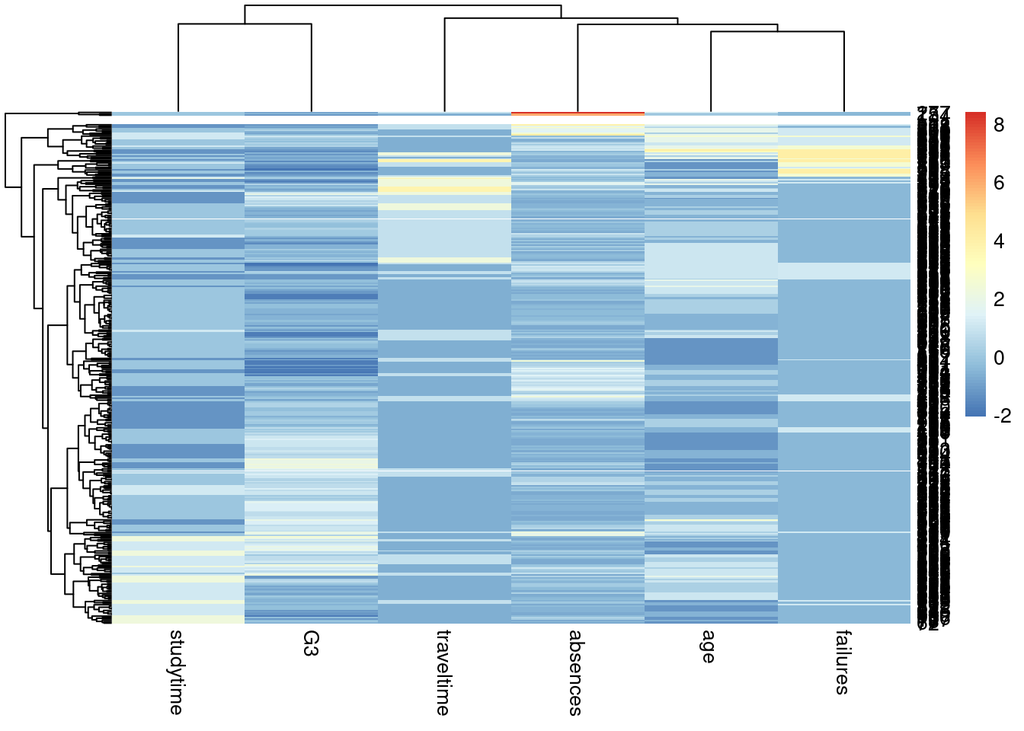

```r
# using PHEATMAP

pheatmap(student3_scaled, cutree_rows = 2)
```

```r
# using D3HEATMAP

# d3heatmap(scale(student3), k_row=4, k_col=2)
```

#### **9. HIERARCHICAL CLUSTERING (CLUSTER TENDENCY)**

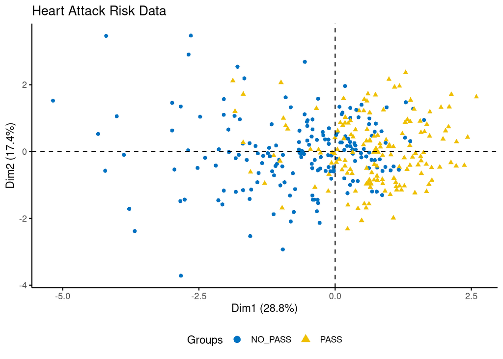

```r
## TRANSFORMING G3 into RANGES of PASS and NO-PASS :

student3$G3 = as.integer(student3$G3)

student3$RESULT[student3$G3 <= 10] = "NO_PASS"
student3$RESULT[student3$G3 >=10 ] = "PASS"

student3 <- subset(student3, select = -c(G3))

student3$RESULT = as.factor(student3$RESULT)

## displaying the PCA analysis :

fviz_pca_ind(prcomp(student3_scaled),
             title="Heart Attack Risk Data",
             habillage = student3$RESULT,
             palette = "jco",
             geom = "point", ggtheme=theme_classic(), legend="bottom" )
```

```r
# Calculating Hopkins Statistics to check if the data does exhibit inherent patterns :

hopkins(student3_scaled, n=nrow(student3_scaled) - 1)
```

```
## $H
## [1] 0.1844118
```

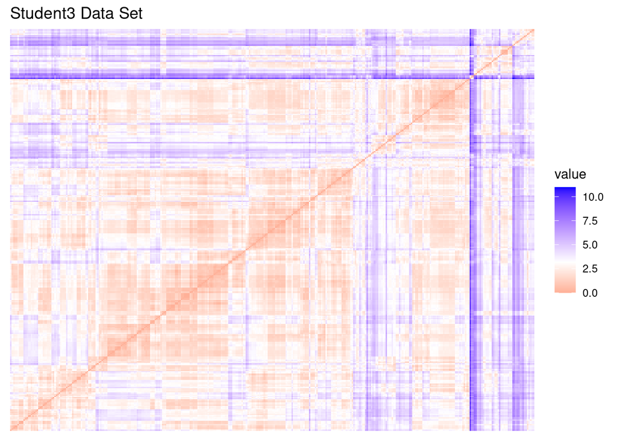

```r
# Visualizing the Dissimilarity Matrix
# where RED depicts high similarity and BLUE low similarity

fviz_dist(dist(student3_scaled), show_labels = FALSE) +
         labs(title = "Student3 Data Set")
```

```r
# using : validation="internal"
cluster_method <- c("hierarchical", "kmeans", "pam", "diana", "agnes")

check <- clValid(student3_scaled,
                 nClust=2:6,
                 clMethods=cluster_method, validation="internal")

summary(check)
```

```
##
## Clustering Methods:
##  hierarchical kmeans pam diana agnes
##
## Cluster sizes:
##  2 3 4 5 6
##
## Validation Measures:
##                                   2        3        4        5        6
##
## hierarchical Connectivity    4.3579  13.6944  25.1456  27.5996  31.3520
##              Dunn            0.1895   0.2597   0.2033   0.2033   0.2033
##              Silhouette      0.4931   0.4669   0.3837   0.3526   0.3072
## kmeans       Connectivity   52.6861 103.7401 109.0377 156.4282  76.1706
##              Dunn            0.0447   0.0324   0.0450   0.0376   0.1357
##              Silhouette      0.3051   0.1945   0.2004   0.1680   0.2219
## pam          Connectivity   90.1119 112.4353 127.4925 169.9107 178.9607
##              Dunn            0.0305   0.0284   0.0300   0.0300   0.0300
##              Silhouette      0.1614   0.1228   0.1340   0.1506   0.1697
## diana        Connectivity   11.6155  32.8206  39.6988  65.1560  66.2250
##              Dunn            0.1392   0.1768   0.1823   0.1363   0.1400
##              Silhouette      0.4674   0.4036   0.3717   0.1944   0.1964
## agnes        Connectivity    4.3579  13.6944  25.1456  27.5996  31.3520
##              Dunn            0.1895   0.2597   0.2033   0.2033   0.2033
##              Silhouette      0.4931   0.4669   0.3837   0.3526   0.3072
##
## Optimal Scores:
##
##              Score  Method       Clusters
## Connectivity 4.3579 hierarchical 2
## Dunn         0.2597 hierarchical 3
## Silhouette   0.4931 hierarchical 2
```

```r
# using : validation="stability"
cluster_method <- c("hierarchical", "kmeans", "pam", "diana", "agnes")

check_stability <- clValid(student3_scaled,
                           nClust=2:6,
                           clMethods=cluster_method, validation="stability")

optimalScores(check_stability)
```

```
##          Score Method Clusters
## APN 0.01297107  agnes        2
## AD  2.53949039    pam        6
## ADM 0.11002497  agnes        2
## FOM 0.96950356    pam        5
```